# PRECIS-2 Scores in PragMeta: Human Consensus vs LMM (Claude 2) - same prompt as for GPT 3.5

### Score comparisons of 56 publications

| Ref. | Author & Year | weighted κ | agreement | pooled weighted κ | pooled agreement |
| --- | --- | --- | --- | --- | --- |
| 648 | CORONIS Collaborative Group (2013) | 0.0228571428571426 | 0.222222222222222 | 0 | 0.444444444444444 |
| 650 | van Dijk-de Vries. A, (2015) | 0.446153846153846 | 0.666666666666667 | 0.217391304347826 | 0.666666666666667 |
| 651 | Price. D, (2011) | 0.0357142857142857 | 0.333333333333333 | -0.125 | 0.666666666666667 |
| 655 | Galdiz, J. B. (2020) | -0.141791044776119 | 0.444444444444444 | -2.22044604925031e-16 | 0.444444444444444 |
| 657 | Arntzen E. (2019) | 0.266666666666667 | 0.111111111111111 | 0.11764705882353 | 0.444444444444444 |
| 662 | Bogosian A. (2015) | 0.357142857142857 | 0.333333333333333 | 0.28 | 0.333333333333333 |
| 663 | Callesen J. (2020) | -0.0879120879120878 | 0.444444444444444 | -0.173913043478261 | 0.666666666666667 |
| 664 | Carter A. (2014) | -0.0327868852459017 | 0.222222222222222 | -0.148936170212766 | 0.333333333333333 |
| 665 | Cooper C. (2011) | -0.140845070422535 | 0.333333333333333 | 0 | 0.777777777777778 |
| 666 | Cutter G. (2019) | 0.244274809160305 | 0.444444444444444 | 0.217391304347826 | 0.444444444444444 |

[output cut: 46 more lines]

### Score heatmaps (unpooled / pooled)

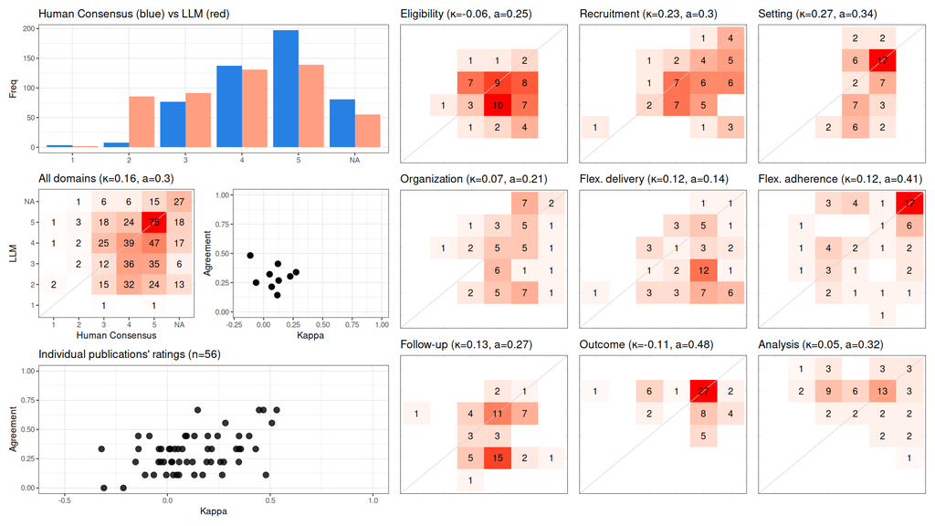

### Individual results

#### 648. CORONIS Collaborative Group (2013): *Caesarean section surgical techniques (CORONIS): a fractional, factorial, unmasked, randomised controlled trial*

PRECIS-2

|  | D1 | D2 | D3 | D4 | D5 | D6 | D7 | D8 | D9 |
| --- | --- | --- | --- | --- | --- | --- | --- | --- | --- |
| Human Consensus | 4 | NA | 5 | 5 | 3 | NA | 5 | 3 | 3 |
| LLM | 5 | 5 | 5 | 5 | 4 | 5 | 4 | 5 | 5 |

LLM response

*8 quote(s) from publication full text (mean similarity 100%)*

```
Here are the PRECIS-2 domain scores for the trial based on the provided full text:

Eligibility:
-"Pregnant women were eligible if they were to undergo delivery by lower segment caesarean section through a transverse abdominal incision, irrespective of fever in labour, gestational age, or multiple pregnancies."

The eligibility criteria seem very inclusive, with few exclusions besides having had more than one previous C-section or already being recruited to the trial. The criteria match what would be used in usual practice.

Score: [5]

Recruitment:
-"Each participating site, advised by their research ethics committee, decided how to provide trial information to women and seek informed consent. Information leaflets were made available, in appropriate languages, which explained the trial objectives, the process of trial entry, and follow-up. The…

Recruitment seems to occur through routine prenatal care. No special efforts like advertising or incentives are mentioned.

Score: [5]

Setting:
-"CORONIS was undertaken at 19 sites in Argentina, Chile, Ghana, India, Kenya, Pakistan, and Sudan."

The settings seem to be routine maternity care facilities where C-sections normally occur.

Score: [5]

Organization:
No details provided on staffing, resources, etc. But given the pragmatic nature of the other domains, it seems reasonable to assume organization mirrors usual care.

Score: [5]

Flexibility (delivery):
-"All non-allocated surgical elements and all other aspects of the caesarean section procedure were undertaken at the discretion of the surgeon."

The interventions were protocolized but other aspects of care were flexible.

Score: [4]

Flexibility (adherence):
- No mention of special efforts to enforce adherence beyond routine clinical encouragement. Compliance was assessed but not enforced: "Compliance with all the allocated interventions was high, 87% overall."

Score: [5]

Follow-up:
-"Data were collected at trial entry, immediately after surgery, at hospital discharge (including hospital transfer or death), and at about 6 weeks after delivery."

Follow-up schedule seems reasonable for a post-surgical trial and does not seem excessive.

Score: [4]

Primary outcome:
-"The primary outcome was a composite of death, maternal infectious morbidity, further operative procedures, or blood transfusion of more than 1 unit of whole blood or packed cells up to the 6-week follow-up visit."

The composite outcome consists of major clinical events that would be of clear importance to patients.

Score: [5]

Primary analysis:
-"Women were analysed in the groups into which they were allocated; for example, comparing women allocated to blunt abdominal entry with those allocated to sharp abdominal entry, regardless of what interventions they actually received."

Analysis seems to be intent-to-treat.

Score: [5]
```

#### 650. [van Dijk-de Vries. A, (2015): *Lessons learnt from a cluster-randomised trial evaluating the effectiveness of Self-Management Support (SMS) delivered by practice nurses in routine diabetes care*](https://doi.org/10.1136/bmjopen-2014-007014)

PRECIS-2

|  | D1 | D2 | D3 | D4 | D5 | D6 | D7 | D8 | D9 |
| --- | --- | --- | --- | --- | --- | --- | --- | --- | --- |
| Human Consensus | 3 | 4 | 5 | 4 | 5 | NA | 4 | 5 | 3 |
| LLM | 3 | 4 | 5 | 4 | 3 | NA | 2 | 5 | NA |

LLM response

*11 quote(s) from publication full text (mean similarity 99.1%)*

```
Here are the PRECIS-2 domain scores with reasoning:

Eligibility:

Relevant quotes:
"Patients with a clinically established diagnosis of type 2 diabetes mellitus were sent a letter by their GPs to introduce the SMS project."
"Patients with score DFT >4 and DS >3 were eligible for trial participation."

Reasoning: The trial recruited patients with an existing diagnosis of type 2 diabetes from routine primary care practices. However, additional eligibility criteria of DFT>4 and DS>3 on screening questionnaires were used to select patients for the trial. This introduces some exclusions beyond usual c…

Score: [3]

Recruitment:

Relevant quotes:
"Patients were sent a letter by their GPs to introduce the SMS project."
"The enclosed self-administered questionnaire consisted of the screening instruments that intervention PNs would also apply for SMS in their routine practice."

Reasoning: Patients were recruited through letters sent by their regular GP introducing the study. This reflects routine practice recruitment fairly well. However, the use of screening questionnaires deviates somewhat from complete usual care.

Score: [4]

Setting:

Relevant quotes:
"All the family practices of one regional organisation of GPs (a so-called ‘care group’) in the South of the Netherlands were eligible to participate in the study."

Reasoning: The study was conducted in routine primary care settings, reflecting the setting where the intervention would be delivered in usual care.

Score: [5]

Organization:

Relevant quotes:
"PNs in the intervention arm were trained to integrate the detection and follow-up phase of SMS into their daily practice."
"Financial reimbursement for the extra time spent on SMS was added to the bundled payment arrangement for diabetes care."

Reasoning: There was some additional training and reimbursement provided to deliver the intervention, but it does not seem substantially different from resources in usual care.

Score: [4]
```

[output cut: 31 more lines]

```
Relevant quotes:
"The effect of SMS on patients’ daily functioning was measured by means of the DFT."

Reasoning: The primary outcome of daily functioning is patient-centered and clinically meaningful.

Score: [5]

Primary analysis:

Relevant quotes:
No relevant quotes about analysis found.

Reasoning: The text does not provide enough information about the primary analysis.

Score: [NA]
```

#### 651. [Price. D, (2011): *Leukotriene antagonists as first-line or add-on asthma-controller therapy*](https://doi.org/10.1056/NEJMoa1010846)

PRECIS-2

|  | D1 | D2 | D3 | D4 | D5 | D6 | D7 | D8 | D9 |
| --- | --- | --- | --- | --- | --- | --- | --- | --- | --- |
| Human Consensus | 5 | 5 | 5 | NA | 4 | 4 | 4 | 5 | 4 |
| LLM | 4 | 4 | 5 | 5 | 3 | NA | 4 | 5 | 5 |

LLM response

*14 quote(s) from publication full text (mean similarity 100%)*

```
Here are the PRECIS-2 scores for each domain based on the provided full text:

Eligibility:

Quotes:
"Eligible primary care patients 12 to 80 years of age had impaired asthma-related quality of life (Mini Asthma Quality of Life Questionnaire [MiniAQLQ] score ≤6) or inadequate asthma control (Asthma Control Questionnaire [ACQ] score ≥1)."

"Other eligibility criteria for both trials included, at screening, a peak expiratory flow (PEF) greater than 50% of the predicted value after an inhaled beta2-agonist had been withheld for 4 hours or longer and, at the baseline visit, evidence of impaired asthma-related quality of life (a score ≤6 …

"Main exclusion criteria were prior treatment within 12 weeks with an inhaled glucocorticoid or LTRA (in the first-line controller therapy trial) or LTRA or LABA (in the add-on therapy trial)."

The eligibility criteria are relatively broad, focusing on impaired asthma control or quality of life. There are some exclusions based on prior treatment, but overall the criteria seem fairly similar to real-world practice.

Score: [4]

Recruitment:

Quotes:
"Study enrollment is shown in Fig. E1 and E2 in the Supplementary Appendix; additional results are detailed in Tables E1 through E28 in the Supplementary Appendix. In both trials, the reason for most exclusions after randomization was a missing MiniAQLQ or ACQ score or a baseline score that was not …

"The trials were conducted at 53 primary care practices in the United Kingdom, enrolled patients 12 to 80 years of age with a physician's diagnosis of asthma."

Patients seem to be recruited through regular primary care clinics, suggesting a pragmatic approach. However, there is limited detail provided on recruitment methods.

Score: [4]

Setting:

Quotes:
"The two trials, which were conducted at 53 primary care practices in the United Kingdom, enrolled patients 12 to 80 years of age with a physician's diagnosis of asthma."

The study is conducted in primary care settings, which matches real-world care.

Score: [5]

Organization:

Quotes:
"Practice staffs were asked to provide each patient with a written individualized asthma-action plan. For each of the assigned treatments, choices of individual drugs and devices were made according to normal clinical practice and British asthma guidelines."

```

[output cut: 39 more lines]

```
Quotes:
"The primary outcome measure was the MiniAQLQ score."

The MiniAQLQ measures asthma quality of life, which is relevant and important to patients.

Score: [5]

Primary analysis:

Quotes:
"The primary effectiveness analysis was an intention-to-treat analysis of the MiniAQLQ score at 2 months (the primary time point) and at 2 years."

The primary analysis was intention-to-treat, a pragmatic approach.

Score: [5]
```

#### 655. [Galdiz, J. B. (2020): *Telerehabilitation Programme as a Maintenance Strategy for COPD Patients: A 12-Month Randomized Clinical Trial*](https://doi.org/10.1016/j.arbres.2020.03.034)

PRECIS-2

|  | D1 | D2 | D3 | D4 | D5 | D6 | D7 | D8 | D9 |
| --- | --- | --- | --- | --- | --- | --- | --- | --- | --- |
| Human Consensus | 3 | NA | 5 | 4 | 5 | 3 | 4 | 3 | 3 |
| LLM | 4 | 4 | 5 | 4 | 3 | 3 | 4 | 5 | 5 |

LLM response

*11 quote(s) from publication full text (mean similarity 100%)*

```
Here are the PRECIS-2 domain scores with reasoning for the given trial:

Eligibility:
"Patient selection criteria were having a diagnosis of moderate-to-severe COPD (a Body mass index, Airflow obstruction, dyspnoea and Exercise capacity [BODE] index score of 3–7) according to international guidelines and having been clinically stable for the previous 4 weeks."
"Overall, 134 patients were screened and 94 were eventually randomized into two groups: 48 to the CG and 46 to the IG."

Reasoning: The study had broad inclusion criteria, enrolling patients with moderate-to-severe COPD who were clinically stable. There were some exclusions like those with significant cognitive impairment. The eligibility seems similar to what would be used in usual care.

Score: [4]

Recruitment:
"Recruited patients (recruitment visit, −1) attended an initial 8-week outpatient-based PR programme conducted in each hospital rehabilitation department."

Reasoning: Patients were recruited during their participation in an initial 8-week PR program. This seems like routine recruitment through standard clinical appointments. No special efforts like advertising or incentives were mentioned.

Score: [4]

Setting:
"This was a multicentre open-label pragmatic parallel-group randomized clinical trial involving 13 hospitals and was conducted between 2014 and 2017."

Reasoning: The study was conducted across 13 hospitals, suggesting a varied real-world setting similar to usual care.

Score: [5]

Organisation:
"Patients in the IG were asked to continue at home with a similar training schedule to that completed in the hospital. They were provided with, for the 12-month follow-up period, a telerehabilitation kit (mobile phone, pulse oximeter, dumbbells and exercise bicycle) along with a user guide with deta…

Reasoning: The intervention involved providing some additional equipment like mobile phones and pulse oximeters to enable remote monitoring. But it did not seem to increase staffing or training significantly beyond usual care.

Score: [4]

Flexibility (delivery):
"They were provided with, for the 12-month follow-up period, a telerehabilitation kit (mobile phone, pulse oximeter, dumbbells and exercise bicycle) along with a user guide with detailed instructions on the use of the mobile device to deliver data collected to the web-based platform after completion…

Reasoning: The intervention group had a structured program to follow with training 3 times per week. This reduces flexibility compared to usual care.

Score: [3]

Flexibility (adherence):
"Patients in the CG received usual care, that is, they were advised to exercise regularly (at least walking for 1 hour a day) and provided with general educational material, following current clinical practice at participating sites."
```

[output cut: 11 more lines]

```

Primary outcome:
"Exercise tolerance (the ability to sustain exercise) was assessed using distance covered in the 6MWT."

Reasoning: The 6MWT is a relevant and validated outcome measure for exercise tolerance in COPD patients. It is important to patients and feasible to implement in usual care.

Score: [5]

Primary analysis:
"All patients were analyzed in the group to which they were randomized."
"Missing values were not imputed. All patients were analyzed in the group to which they were randomized."

Reasoning: Analysis seems to follow intention-to-treat principles with no exclusions.

Score: [5]
```

#### 657. [Arntzen E. (2019): *Group-Based Individualized Comprehensive Core Stability Intervention Improves Balance in Persons With Multiple Sclerosis: A Randomized Controlled Trial.*](https://doi.org/10.1093/ptj/pzz017)

PRECIS-2

|  | D1 | D2 | D3 | D4 | D5 | D6 | D7 | D8 | D9 |
| --- | --- | --- | --- | --- | --- | --- | --- | --- | --- |
| Human Consensus | 3 | 4 | 5 | 4 | 5 | 4 | 4 | 5 | 5 |
| LLM | 3 | 3 | 4 | 3 | 3 | 3 | 3 | 4 | 4 |

LLM response

*13 quote(s) from publication full text (mean similarity 100%)*

```
Here are the PRECIS-2 domain scores with quotes and explanations:

Eligibility:

Quotes:
"Inclusion criteria were as follows: (1) diagnosed with MS in accordance with the McDonald criteria27; (2) registered at the MS outpatient clinic; (3) living in 1 of 6 selected municipalities; (4) aged 18 years or older; (5) capable of providing signed written informed consent; and (6) EDSS score be…

"Among the 93 individuals who consented to participate, 13 were not included: 5 could not commit the time, 3 scored 0 on the EDSS, 2 did not attend the baseline assessment, 1 was waiting for heart surgery, 1 was pregnant, and 1 had moved out of the catchment area."

The eligibility criteria reflect typical inclusion/exclusion criteria for an MS clinical trial, including confirmed diagnosis, age, disability level, ability to consent, and excluding acute exacerbations. The EDSS range of 1-6.5 represents a broad range of disability levels among ambulatory patients…
Score: [3]

Recruitment:

Quotes:
"In August 2015, 1 of the MS nurses at the Department of Neurology, Nordland Hospital Trust in Bodø, Norway, sent out invitation letters with a consent form to 160 persons with MS who were registered at the MS outpatient clinic, had EDSS scores of 0 to 7, and lived in 1 of the 6 municipalities inclu…

"To ensure maximum patient enrollment, 1 reminder letter was sent out to the nonresponders."

Patients were recruited through an MS clinic registry, reflecting typical recruitment in clinical practice. One reminder letter was sent to encourage recruitment, but no other special efforts were made. Overall, recruitment was moderately pragmatic.
Score: [3]

Setting:

Quote:
"The GroupCoreDIST intervention was conducted by 6 physical therapists in 6 municipalities in Norway."

The intervention was delivered in participants' local municipalities by physical therapists working in those areas. This reflects a typical clinical setting.
Score: [4]

Organisation:

Quote:
"Six neurological physical therapists conducted the intervention after being trained in GroupCoreDIST for 5 days."

The physical therapists received specialized training in the intervention, which is more resources than would be typical in standard care. However, they did not require extensive extra qualifications beyond their existing clinical roles. The organization was moderately pragmatic.
Score: [3]

Flexibility (delivery):

```

[output cut: 26 more lines]

```
Primary outcome:

Quotes:
"The outcome measures were the Trunk Impairment Scale–Norwegian Version (TIS-NV), the Mini Balance Evaluation Systems Test (Mini-BESTest), and the Patient Global Impression of Change–Balance (PGIC-Balance)."

The TIS-NV and Mini-BESTest are standardized clinical outcome measures focused on balance and trunk control. The outcomes are clinically meaningful for patients.
Score: [4]

Primary analysis:

Quote:
"To examine possible differences between groups over time, we performed an intention-to-treat analysis using repeated-measures mixed models in IBM SPSS Version 24."

An intention-to-treat analysis was used, reflecting a pragmatic approach.
Score: [4]
```

#### 662. [Bogosian A. (2015): *Distress improves after mindfulness training for progressive MS: A pilot randomised trial*](https://doi.org/10.1177/1352458515576261)

PRECIS-2

|  | D1 | D2 | D3 | D4 | D5 | D6 | D7 | D8 | D9 |
| --- | --- | --- | --- | --- | --- | --- | --- | --- | --- |
| Human Consensus | 5 | 4 | 5 | 4 | 3 | NA | 3 | 5 | 5 |
| LLM | 3 | 3 | 5 | 3 | 2 | 3 | 3 | 3 | 5 |

LLM response

*15 quote(s) from publication full text (mean similarity 100%)*

```
Here are the PRECIS-2 domain scores for the trial described in the full text:

Eligibility:
Quotes:
"Inclusion criteria were diagnosis of PPMS or SPMS, Internet access and some level of distress determined by a score of 3 or greater on the General Health Questionnaire (GHQ-12)."
"Exclusion criteria were severe cognitive impairment, as determined by a score of 20 or smaller on the Telephone Interview for Cognitive Status-Modified (TICS-M) and high suicide risk, as assessed by a score of 20 or greater on the Clinical Outcome of Routine Evaluation (CORE-10)."

The eligibility criteria are moderately pragmatic. The trial included patients with progressive MS, which matches usual care. However, participants were screened for distress and excluded if they had severe cognitive impairment or high suicide risk. While appropriate for a trial, these additional in…
Score: [3]

Recruitment:
Quotes:
"Recruitment took place between December 2012 and May 2013. We administered the screening questionnaires via telephone."
"Reasons for not attending included: medical appointments, planned holidays, pain/fatigue and technical problems, e.g. computer virus, stolen computer, problems with audio."

The recruitment process was moderately pragmatic. Participants were recruited through advertisements and NHS centers, which requires some extra effort beyond usual care. However, they completed screening questionnaires remotely by telephone. The reasons for missing sessions also reflect real-world s…
Score: [3]

Setting:
Quotes:
"We delivered the programme in eight hour-long sessions over an eight-week period via Skype video conferences."

The setting is very pragmatic. The intervention was delivered remotely using Skype, matching how it would be implemented in routine practice. No special trial centers or facilities were used.
Score: [5]

Organization:
Quotes:
"AB, a health psychologist, facilitated the courses. AB was supervised by PC, a clinical psychologist and expert mindfulness practitioner."
"The format and manual for the mindfulness group, including length of sessions and individual mindfulness practices, were developed in partnership with patients with MS through initial experimental case studies."

The organization is moderately pragmatic. The mindfulness teacher had training in psychology and mindfulness, which provides some additional resources compared to routine care delivery. However, the intervention format and materials were developed specifically for MS patients through case studies, m…
Score: [3]

Flexibility (delivery):
Quotes:
"We restricted the number of participants to five for each group based on Skype user guidance, which suggests the quality of videoconferences drops with more than this number."
"The eight chapters, one for each session, introduced key mindfulness concepts, addressed issues common to progressive MS, and described homework for the week ahead."

The delivery of the intervention has low flexibility like an explanatory trial. The sessions followed a structured manual and participants received audio recordings and guides for home practice. The group size was restricted. This level of standardization is not reflective of how mindfulness trainin…
Score: [2]
```

[output cut: 15 more lines]

```

Primary outcome:
Quotes:
"The GHQ is uncontaminated by the experience of MS-related somatic symptoms and is the most treatment-responsive measure of psychological distress in MS."
"Higher scores on this scale represent high distress."

The primary outcome is moderately pragmatic. The GHQ measures general psychological distress rather than MS symptoms specifically. However, it is still a standardized self-report measure unlike outcomes measured in routine care.
Score: [3]

Primary analysis:
Quote:
"We conducted all group comparisons on an intention-to-treat basis where we analysed participants in the group to which they were randomised."

The analysis is very pragmatic. All randomized participants were included in the analysis following the intention-to-treat principle, similar to how data would be analyzed in routine practice.
Score: [5]
```

#### 663. [Callesen J. (2020): *How do resistance training and balance and motor control training affect gait performance and fatigue impact in people with multiple sclerosis? A randomized controlled multi-center study*](https://doi.org/10.1177/1352458519865740)

PRECIS-2

|  | D1 | D2 | D3 | D4 | D5 | D6 | D7 | D8 | D9 |
| --- | --- | --- | --- | --- | --- | --- | --- | --- | --- |
| Human Consensus | 4 | 4 | 5 | 5 | 5 | 5 | 4 | 5 | 3 |
| LLM | 4 | 3 | 5 | 4 | 3 | 4 | 4 | 5 | 5 |

LLM response

*5 quote(s) from publication full text (mean similarity 100%)*

```
Here are the PRECIS-2 domain scores for the provided trial text:

Eligibility:

"Participants were included from September 2016 to October 2018, after being invited via seven MS clinics (specified in “Acknowledgements” section) and targeted advertisements sent out via the Danish MS Society."

"The inclusion criteria were as follows: age > 18, confirmed diagnosis of MS, Expanded Disability Status Scale (EDSS): 2.0–6.5, Six Spot Step Test (SSST) score > 8 seconds or Timed 25-Foot Walk (T25FW) > 5 seconds, relapse-free within the past 8 weeks, and no adjustment of disease-modifying medicati…

"Exclusion criteria were as follows: co-morbidity in terms of cognitive disorders or alcohol abuse (based on clinical judgment), pathologies that did not allow systematic PRT >1 session/week within the last 3 months."

The trial recruited participants from MS clinics and had inclusion/exclusion criteria typical for an MS intervention trial. While it excluded some patients, the criteria seem generally pragmatic and similar to what would be used in clinical practice.

Score: [4]


Recruitment:

"Participants were included from September 2016 to October 2018, after being invited via seven MS clinics (specified in “Acknowledgements” section) and targeted advertisements sent out via the Danish MS Society."

Participants were recruited through MS clinics and advertisements, which required some extra effort beyond routine clinical practice. However, the recruitment still seems reasonably pragmatic.

Score: [3]


Setting:

No direct quotes, but the paper states the interventions were delivered at local physiotherapy clinics. This matches routine clinical practice.

Score: [5]


Organization:

No clear quotes, but the interventions were delivered by physiotherapists at local clinics, similar to typical clinical practice.

Score: [4]


Flexibility (delivery):

```

[output cut: 18 more lines]

```

Primary outcome:

The primary outcomes were gait speed (T25FW) and a test of walking requiring multiple direction changes (SSST). These are clinically meaningful for MS patients.

Score: [5]


Primary analysis:

"Analyses were carried out as intention-to-treat, where all participants who completed the baseline assessment were included regardless of their adherence to the allocated intervention."

An intention-to-treat analysis was used.

Score: [5]
```

#### 664. [Carter A. (2014): *Pragmatic intervention for increasing self-directed exercise behaviour and improving important health outcomes in people with multiple sclerosis: a randomised controlled trial*](https://doi.org/10.1177/1352458513519354)

PRECIS-2

|  | D1 | D2 | D3 | D4 | D5 | D6 | D7 | D8 | D9 |
| --- | --- | --- | --- | --- | --- | --- | --- | --- | --- |
| Human Consensus | 3 | 4 | 4 | 5 | 5 | 3 | 4 | 5 | 4 |
| LLM | 3 | 3 | 3 | 2 | 3 | 4 | 2 | 5 | 5 |

LLM response

*10 quote(s) from publication full text (mean similarity 100%)*

```
Here are the PRECIS-2 domain scores and justifications:

Eligibility:

Quote 1: "The inclusion criteria for the trial were clinical diagnosis of MS, as defined by the modified McDonald criteria, with an Expanded Disability Status Scale (EDSS) score of 1.0–6.5, and able to walk a 10-metre distance; aged 18–65 years; clinically stable for at least four weeks prior to ent…

The eligibility criteria are reasonably broad, including patients with mild to moderate MS who are ambulatory and stable. This is likely similar to eligibility for exercise programs in usual care. However, the upper age limit of 65 excludes older patients who may benefit.

Score: [3]

Recruitment:

Quote 1: "A total of 120 PwMS were recruited via the Sheffield MS Clinic and flyers/community adverts displayed at the local South Yorkshire MS Society branches."

Quote 2: "Many eligible PwMS declined to take part in the study without giving a reason (N = 126; 66%) and a more comprehensive understanding of the barriers and facilitators to exercise in PwMS could be used to inform the design of future programmes."

Recruitment was done through routine clinic visits and community adverts. No extraordinary efforts like newspaper ads or incentives were used. However, many patients declined to participate, suggesting recruitment was challenging.

Score: [3]

Setting:

Quote: "During weeks 1–6, participants attended two supervised sessions per week at a university exercise research facility and engaged in one additional self-directed exercise session in their home environment."

The setting included both a specialized research facility as well as the patient's home environment. While not identical to usual care, it does incorporate community-based exercise.

Score: [3]

Organization:

Quote: "The supervised exercise sessions incorporated cognitive-behavioural techniques (e.g. goal setting, finding social support, understanding the costs/benefits of exercise, etc.) to promote long-term participation in physical activity."

The intervention provided additional training in behavioral techniques and likely had more staffing and resources compared to usual care.

Score: [2]

Flexibility (delivery):

Quote: "The home-exercise sessions were intended to mirror the supervised sessions in terms of intensity and duration of aerobic exercise, and also included tailored exercises for strength, flexibility and balance."

```

[output cut: 20 more lines]

```
Primary outcome:

Quote: "The primary outcome was self-reported exercise behaviour at three months using the Godin Leisure Time Exercise Questionnaire (GLTEQ)."

The primary outcome of self-reported exercise is highly patient-centered and pragmatic.

Score: [5]

Primary analysis:

Quote: "All analyses were by intention to treat, whereby participants were analysed in the arm to which they were randomised irrespective of whether they complied with the intervention."

The primary analysis was a pragmatic intention-to-treat approach.

Score: [5]
```

#### 665. [Cooper C. (2011): *Computerised cognitive behavioural therapy for the treatment of depression in people with multiple sclerosis: external pilot trial*](https://doi.org/10.1186/1745-6215-12-259)

PRECIS-2

|  | D1 | D2 | D3 | D4 | D5 | D6 | D7 | D8 | D9 |
| --- | --- | --- | --- | --- | --- | --- | --- | --- | --- |
| Human Consensus | 4 | 4 | 5 | 5 | 5 | 4 | 4 | 5 | 4 |
| LLM | 3 | 4 | 4 | 4 | 4 | 4 | 4 | 3 | 5 |

LLM response

*14 quote(s) from publication full text (mean similarity 97.5%)*

```
Here are the PRECIS-2 domain scores for the trial based on the provided full text:

Eligibility

Relevant quotes:
- "Inclusion criteria were: age of 18 years or above; BDI score of at least 14 on two consecutive occasions and no treatment from psychologist, psychotherapist or psychiatrist within the last three months."
- "Exclusion criteria were: poor English language skills or cognitive function (score of less than 24 on Mini Mental State Examination [20]); BDI score of at least 29 on two consecutive occasions; active suicidal ideas; current or life-time diagnosis of psychosis, organic mental disorder or substanc…

The eligibility criteria are fairly broad, including adults with MS and mild to moderate depression based on BDI scores. However, some patients are excluded, like those with severe depression, cognitive impairment, psychosis, etc. Overall, the criteria attempt to target patients similar to those who…

Score: [3]


Recruitment

Relevant quotes:
- "At Sheffield potential participants were identified from clinic attenders, MS nurse patient visits and from patients with MS from the caseload of the neuropsychologist. At the Walton Centre potential participants were identified solely from the MS register."

Participants were recruited through routine clinic visits and an MS registry, reflecting usual methods to engage patients in care. No extraordinary recruitment efforts like advertising or incentives were used.

Score: [4]


Setting

Relevant quotes:
- "The study was conducted at two UK centres - Sheffield Teaching Hospitals NHS Foundation Trust and The Walton Centre NHS Foundation Trust, Liverpool."

The settings were routine NHS hospital clinics rather than specialized trial or academic centers. This matches the setting where patients would receive CCBT in usual care.

Score: [4]


Organisation

Relevant quote:
- "The CCBT service provided to trial participants was the routine service provided to all patients referred to the PCT mental health care teams."

The CCBT intervention arm received the same organizational resources and delivery model as in usual NHS care. No additional staffing, training, etc. was provided.

```

[output cut: 40 more lines]

```
- "Participants found problems with the face validity of the depression inventories which include somatic symptoms of depression which are also symptoms of MS."

The BDI is a common depression scale, though participants questioned its face validity. It measures an important outcome but earlier than in usual care.

Score: [3]


Primary analysis

Relevant quote:
- "Primary analysis was an Intention To Treat (ITT) analysis which analysed all 24 participants according to their randomised treatment assignment ignoring non compliance, protocol deviations and withdrawal."

An intention-to-treat analysis was used including all participants as randomized. This matches usual care.

Score: [5]
```

#### 666. [Cutter G. (2019): *Higher satisfaction and adherence with glatiramer acetate 40 mg/mL TIW vs 20 mg/mL QD in RRMS*](https://doi.org/10.1016/j.msard.2019.04.036)

PRECIS-2

|  | D1 | D2 | D3 | D4 | D5 | D6 | D7 | D8 | D9 |
| --- | --- | --- | --- | --- | --- | --- | --- | --- | --- |
| Human Consensus | 4 | NA | 5 | NA | NA | 4 | 3 | 5 | 5 |
| LLM | 3 | NA | 2 | NA | 2 | NA | 3 | 5 | NA |

LLM response

*8 quote(s) from publication full text (mean similarity 100%)*

```
Here are my assessments for each PRECIS-2 domain based on the provided full text:

Eligibility:

Quotes:
"Key inclusion criteria permitted the participation of men or women ≥18 years of age with confirmed and documented RRMS diagnosis (as defined by the Revised McDonald criteria) (Polman et al., 2011), Kurtzke Expanded Disability Status Scale (EDSS) score of 0 to 5.5 at the screening visit, and, 30 day…

"Key exclusion criteria were previous exposure to GA40, a progressive form of MS or neuromyelitis optica, the use of experimental or investigational drugs, participation in clinical drug studies within the 6 months before screening, recent use of immunosuppressive medications or immunoglobulins/mono…

Score: [3]

The eligibility criteria seem moderately pragmatic. They allow a broad range of adult RRMS patients to participate, with some restrictions on prior treatments and disease activity. However, they exclude patients with progressive MS or neuromyelitis optica, which limits generalizability. Overall, a m…

Recruitment:

Quotes: No relevant quotes found.

Score: [NA]

The text does not provide details on the recruitment methods used in the trial.

Setting:

Quotes:
"This trial was registered with ClinicalTrials.gov (NCT02499900)."

"The study protocol was approved by Independent Ethics Committees or Institutional Review Boards according to national or local regulations."

Score: [2]

The trial was conducted across multiple countries which suggests a pragmatic setting. However, participants were recruited at study centers and the protocol required ethics approval, indicating a more explanatory design. Overall, the setting seems moderately explanatory.

Organisation:

Quotes: No relevant quotes found.

Score: [NA]

The text does not provide information about the resources, provider expertise, or organization of care delivery compared to usual care.

```

[output cut: 29 more lines]

```

Quotes:
"All endpoints were compared between the GA40 and GA20 treatment groups during the 6-month treatment period. Patient-reported endpoints used self-reported questionnaires, whereas safety endpoints were assessed by the physicians. The primary endpoint was patient overall satisfaction with the medicati…

Score: [5]

The primary outcome is patient satisfaction measured by a simple 7-point scale. This is a highly pragmatic choice focused on subjective patient experience rather than an objective biomarker or clinical endpoint.

Primary analysis:

Quotes: No relevant quotes about analysis methods found.

Score: [NA]

The text does not provide information about the primary analysis methods.
```

#### 668. [Dodd K. J. (2011): *Progressive resistance training did not improve walking but can improve muscle performance, quality of life and fatigue in adults with multiple sclerosis: a randomized controlled trial*](https://doi.org/10.1177/1352458511409084)

PRECIS-2

|  | D1 | D2 | D3 | D4 | D5 | D6 | D7 | D8 | D9 |
| --- | --- | --- | --- | --- | --- | --- | --- | --- | --- |
| Human Consensus | 4 | 3 | 5 | 5 | NA | 4 | 4 | 5 | 4 |
| LLM | 3 | 3 | 5 | 3 | 3 | NA | 3 | 5 | 5 |

LLM response

*13 quote(s) from publication full text (mean similarity 100%)*

```
Here are the PRECIS-2 domain scores for the given clinical trial publication:

Eligibility

Quotes:
- "To be included, people had to be aged 18 years or more, have a confirmed diagnosis of relapsing–remitting MS, have an Ambulation Index score19 of 2, 3 or 4 (mild to moderate walking disabilities), and have received medical clearance to participate."
- "Volunteers were excluded if they had an acute exacerbation of MS within 2 months of starting the program, had benign or progressive/relapsing types of MS, had a serious unstable medical condition, had any concurrent condition, for example stroke, or had participated in a PRT program in the 6 mont…

The eligibility criteria are specific to people with relapsing-remitting MS who have mild to moderate walking disability. They exclude other types of MS and other concurrent medical conditions. Overall, the criteria seem moderately pragmatic and aim to recruit a specific population of interest.

Score: [3]

Recruitment

Quotes:
- "Participants were recruited through a statewide organization providing education and support to people with MS, and a large specialist MS outpatient clinic."
- "Recruitment information flyers were sent by mail to all potential participants registered on the mailing lists of both organizations. If interested, volunteers were asked to contact one of the researchers (KD) by telephone, during which volunteers were screened to ensure they satisfied the inclus…

Participants were recruited through MS support organizations rather than advertisements or referrals from clinics. This seems moderately pragmatic.

Score: [3]

Setting

Quotes:
- "The experimental group completed a 10-week (two times per week), PRT program in one of four community gymnasiums in metropolitan and regional areas."

The training took place in community gymnasiums rather than specialized trial centers. This is very pragmatic.

Score: [5]

Organization

Quotes:
- "Each program was attended by a group of up to 12 participants, and they were supervised by up to three experienced trainers (physiotherapists and registered personal sports trainers). Each trainer directly supervised a sub-group of three or four participants."
- "The training also took the form of small group-based training; this is important because it made exercising a more social activity, and it was more cost effective and time efficient than individual training."

The training was delivered in a group format with experienced trainers. This seems moderately pragmatic.

Score: [3]
```

[output cut: 29 more lines]

```
- "Changes in walking endurance were measured with the 2-minute walk test (2MWT)"
- "Changes in maximal walking speed were measured by recording the time taken to walk the middle 10 m of a level 14-m walkway using a stopwatch"

The primary outcomes of walking endurance and speed are highly relevant for participants and measure functional ability. This is very pragmatic.

Score: [5]

Primary analysis

Quote:
- "Intention-to-treat analysis was applied, with all participants who were allocated and commenced their program included in analysis. Where data were missing, the carry forward technique was used."

An intention-to-treat analysis was used. This is very pragmatic.

Score: [5]
```

#### 669. [Feys P. (2019): *Effects of an individual 12-week community-located “start-to-run” program on physical capacity, walking, fatigue, cognitive function, brain volumes, and structures in persons with multiple sclerosis*](https://doi.org/10.1177/1352458517740211)

PRECIS-2

|  | D1 | D2 | D3 | D4 | D5 | D6 | D7 | D8 | D9 |
| --- | --- | --- | --- | --- | --- | --- | --- | --- | --- |
| Human Consensus | 3 | 4 | 5 | 2 | 5 | 2 | 1 | 3 | 3 |
| LLM | 4 | 3 | 3 | 4 | 3 | 3 | 4 | 5 | 5 |

LLM response

*9 quote(s) from publication full text (mean similarity 99.6%)*

```
Here are the PRECIS-2 domain scores and explanations for the given clinical trial text:

Eligibility:

Quote: "Adults diagnosed with MS were included based on the ability to walk 5 km without rest or use of assistive device."

Reasoning: The study had quite broad eligibility criteria - adults with MS who could walk 5km without assistance. This matches eligibility in usual care reasonably well. There were no exclusions based on factors like comorbidities, age, disease duration, etc.

Score: [4]

Recruitment:

Quote: "Adults with MS were recruited through announcements at REVAL rehabilitation research institute (UHasselt), Flemish MS rehabilitation centers and MS Society, and Move-to-Sport."

Reasoning: Participants were recruited through rehabilitation centers, MS society and a sports program. This involved some additional effort beyond routine referrals at usual care clinics.

Score: [3]

Setting:

Quote: "Evaluation was performed at REVAL by a study nurse, a PhD student in Rehabilitation Sciences and Physiotherapy, and the project dedicated researcher (MSc in exercise physiology, PhD)."

Reasoning: Assessments were done at a research institute, not routine clinical settings. Participants did their exercise training in the community.

Score: [3]

Organisation:

Quote: "pwMS received training instructions by email. They were asked to train three times weekly according to a personalized training intensity schedule that was based on their baseline aerobic capacity."

Reasoning: The exercise program was delivered with remote supervision by email. Participants did the training on their own in the community. This matches usual care reasonably closely in terms of resources and provider expertise.

Score: [4]

Flexibility (delivery):

Quote: "pwMS wore an activity tracker (Withings Pulse Ox) at the waist that registered the intensity of steps per minute. Participants were asked to weekly upload data to allow remote supervision of the training adherence by the research assistant."

Reasoning: Participants followed a prescribed personalized training plan with intensity monitoring and E-monitoring. There was some flexibility in terms of when and where to exercise, but overall the delivery was fairly protocolized.

```

[output cut: 18 more lines]

```
Primary outcome:

Quote: "The primary outcome measures were physical fitness, walking capacity and perceived ability, functional mobility, and quality of life."

Reasoning: The primary outcomes of fitness, walking ability, mobility and quality of life are clinically meaningful to patients.

Score: [5]

Primary analysis:

Quote: "Intention-to-treat analysis was performed."

Reasoning: An intention-to-treat analysis was done, implying that all randomized participants were included. This matches real-world practice.

Score: [5]
```

|  | D1 | D2 | D3 | D4 | D5 | D6 | D7 | D8 | D9 |
| --- | --- | --- | --- | --- | --- | --- | --- | --- | --- |
| Human Consensus | 5 | 5 | 4 | 5 | 5 | NA | NA | 5 | NA |
| LLM | 4 | 4 | 4 | NA | 4 | NA | 2 | 5 | 5 |

LLM response

*10 quote(s) from publication full text (mean similarity 100%)*

```
Here are the PRECIS-2 domain scores for the clinical trial described in the full text:

Eligibility:
"The inclusion criterion for the study was a diagnosis of multiple sclerosis, and therefore the spectrum of clinical presentations was broad, as would be expected in this client population."
"Clients were provided with information about the clinic by the local chapter of the Multiple Sclerosis Society, and self selected on that basis. Of the fifteen study participants, all had previously received a diagnosis of multiple sclerosis."

The eligibility criteria included a diagnosis of MS, which aligns with usual care. The broad spectrum of MS presentations and self-selection of participants makes the trial pragmatic in terms of resembling real-world practice.

Score: [4]


Recruitment:
"Clients attending the clinic were interviewed, and their case histories recorded. The research project was explained, and written informed consent was obtained."

Participants were recruited during their regular clinic visits, which is a pragmatic approach. There is no mention of using advertisements or incentives that would make recruitment more explanatory.

Score: [4]


Setting:
"An appropriate history and physical examination was performed, and a treatment plan determined, this being reflective of the therapist's assessment and the mutually set goals for the treatment series."
"All treatment plans were approved by the clinical teacher in charge. The teacher also monitored treatment delivery, which involved the application of a variety of techniques appropriate to the client's needs."

The setting was a student teaching clinic, which may not exactly match real-world practice but is still reasonably pragmatic. Treatments reflected usual massage therapy care.

Score: [4]


Organisation:
No relevant quotes.

The text does not provide information about staffing, resources, or organization of care delivery.

Score: [NA]


Flexibility (delivery):
"The heterogeneity of the client/participant population precluded an overly prescriptive approach to treatment, and it is worth noting that this heterogeneity is also a component of the normal clinical reality of therapists involved with multiple sclerosis clients."
"The teacher also monitored treatment delivery, which involved the application of a variety of techniques appropriate to the client's needs."

```

[output cut: 19 more lines]

```


Primary outcome:
"The outcome measures for the current research were the scores yielded by the Multiple Sclerosis Self Efficacy (MSSE) survey."

The primary outcome of self-efficacy is patient-centered and pragmatic. No surrogate or clinical measures were used.

Score: [5]

Primary analysis:
"The data were analyzed on an intention to treat basis, with a focus on the differences between mean MSSE values of the control and intervention groups."

The intention-to-treat analysis is pragmatic and includes all participants.

Score: [5]
```

#### 671. Freeman J. (2019): *Assessment of a home-based standing frame programme in people with progressive multiple sclerosis (SUMS): a pragmatic, multi-centre, randomised, controlled trial and cost-effectiveness analysis*

PRECIS-2

|  | D1 | D2 | D3 | D4 | D5 | D6 | D7 | D8 | D9 |
| --- | --- | --- | --- | --- | --- | --- | --- | --- | --- |
| Human Consensus | 5 | 5 | 5 | 4 | 3 | 2 | 3 | 5 | 3 |
| LLM | 4 | 5 | 5 | 5 | 4 | 5 | 4 | 5 | 5 |

LLM response

*14 quote(s) from publication full text (mean similarity 100%)*

```
Here are the PRECIS-2 domain scores and explanations based on the provided full text:

### Eligibility
Relevant quotes:
- "Key inclusion criteria were age older than 18 years, a diagnosis of progressive multiple sclerosis (primary or secondary) according to McDonald's criteria,21 and a score of 6·5–8·0 on the Expanded Disability Status Scale (EDSS)."
- "Key exclusion criteria were being within 3 months of ceasing a multiple sclerosis disease-modifying drug, receiving steroid treatment within the preceding month, or participating in another clinical trial."

The inclusion criteria focused on adults with progressive MS and significant mobility impairment based on EDSS scores. The exclusions were minimal, related to recent medication changes. Overall, the criteria reflect a typical MS population that would receive this intervention in usual care.

Score: [4]

### Recruitment
Relevant quotes:
- "Participants were recruited through eight health-care organisations, including the UK National Health Service (NHS) Trusts, social enterprises, and third sector multiple sclerosis therapy centres, in two regions (Devon–Cornwall and East Anglia) of the UK."
- "Individuals were invited consecutively until the allocated number of standing frames (dependent on commissioning costs) at each health-care organisation had been reached."

Participants were recruited through routine health care organizations, rather than through advertisements or other special recruitment efforts. This pragmatic approach mirrors how patients would access this intervention in real-world practice.

Score: [5]

### Setting
Relevant quotes:
- "The intervention consisted of two home-based physiotherapy sessions (60 min each) to set up the standing frame programme, supported by six follow-up telephone calls (15 min per call)."
- "Participants were asked to stand for 30 min, three times per week over 20 weeks, and encouraged to continue in the longer term, although no further physiotherapy support was provided."

The intervention was delivered entirely within participants' own homes, the same setting where it would be implemented in usual care.

Score: [5]

### Organization
Relevant quote:
- "The use of standing frames is a recognised core skill for UK-trained neurological physiotherapists. To standardise and optimise implementation of the intervention, we provided educational materials and assessed fidelity to them.16 All participants received their usual health and social service in…

The physiotherapists delivering the intervention were those already working in the participating NHS organizations, without additional training or resources provided. This matches how the intervention would be organized and delivered in real-world practice.

Score: [5]

### Flexibility (delivery)
Relevant quotes:
- "In line with previous research,14 participants were asked to stand in the frame for 30 min three times per week over 20 weeks, and to record the frequency and duration of each stand in a daily diary."
```

[output cut: 23 more lines]

```
### Primary outcome
Relevant quote:
- "The primary outcome was motor function as measured by the Amended Motor Club Assessment (AMCA) score23 at the primary endpoint of 36 weeks post-randomisation. This score was developed for use by physiotherapists in a clinical setting to assess motor function in people with multiple sclerosis and …

The AMCA scale measures functional mobility and motor impairment, outcomes that are clinically meaningful to patients. It was specifically developed for assessing MS patients in clinical settings.

Score: [5]

### Primary analysis
Relevant quote:
- "The primary analysis of the primary outcome, AMCA score at 36 weeks, followed a modified intention-to-treat approach, regardless of compliance to the intervention, but did exclude patients who were deemed ineligible after randomisation, those who withdrew from the trial and were unwilling for the…

The primary analysis was modified ITT, including all participants with baseline and final data regardless of compliance. This pragmatic approach mirrors how data would be analyzed in real-world practice.

Score: [5]
```

#### 673. [Garrett M. (2013): *Exercise in the community for people with minimal gait impairment due to MS: an assessor-blind randomized controlled trial*](https://doi.org/10.1177/1352458512461966)

PRECIS-2

|  | D1 | D2 | D3 | D4 | D5 | D6 | D7 | D8 | D9 |
| --- | --- | --- | --- | --- | --- | --- | --- | --- | --- |
| Human Consensus | 5 | 5 | 5 | NA | 3 | 3 | 5 | 5 | 2 |
| LLM | 3 | 3 | 5 | 3 | 3 | 4 | 4 | 4 | 5 |

LLM response

*9 quote(s) from publication full text (mean similarity 100%)*

```
Here are the PRECIS-2 domain scores and explanations:

## Eligibility

Quotes:
"Eligible participants were over 18 years of age and had a diagnosis of MS that was confirmed by a consultant physician or neurologist. Persons with MS were excluded if they had a previous relapse or began steroid therapy in the 12 weeks prior to participating in the first assessment, were pregnant,…

The eligibility criteria seem fairly broad, including adults with confirmed MS diagnosis who did not have a recent relapse or other issues preventing exercise. Some participants with comorbidities were excluded if they impacted exercise ability. Overall, the criteria seem moderately pragmatic.

Score: [3]

## Recruitment

Quotes:
"Participants were enrolled following their eligibility assessments, performed by the regional offices of MSI. Once consent for eight people of a strand in a specific geographical area was obtained, the regional office of MSI contacted the national coordinator (AL) who allocated that block of partic…

"Our study participants were referred to the project by themselves, their care-giver, MSI, chartered physiotherapists, neurologists, general practitioners or clinical nurse specialists."

Recruitment was done through regional MS offices and healthcare providers, allowing self-referral. No special efforts like advertising or incentives were mentioned. This approach seems moderately pragmatic.

Score: [3]

## Setting

Quotes:
"All interventions took place in groups of eight, for an hour per week, for 10 weeks. They were delivered in community centres such as local gyms, hotels and health centres."

The interventions were delivered in community settings like gyms and health centers. This is very pragmatic.

Score: [5]

## Organization

Quotes:
"In the PT-led programme, there was a home exercise component consisting of 10 aerobic sessions to be performed during weeks 1 – 5 (i.e. resulting in a frequency of two per week)."

The interventions were led by physiotherapists, fitness instructors, and yoga instructors. No mention of increased staffing levels or resources. Seems moderately pragmatic.

Score: [3]

```

[output cut: 28 more lines]

```
Quotes:
"The primary outcome measure was the physical component of the Multiple Sclerosis Impact Scale- 29, version 2 (MSIS-29v2), a patient-reported outcome measure that assesses the physical impact of MS."

The primary outcome was patient-reported physical impact of MS, which is pragmatic.

Score: [4]

## Primary analysis

Quotes:
"All participants were analysed in the groups to which they were randomised."

An intention-to-treat analysis was used, which is pragmatic.

Score: [5]
```

#### 674. [Giovannoni G. (2016): *Alemtuzumab improves preexisting disability in active relapsing-remitting MS patients*](https://doi.org/10.1212/WNL.0000000000003319)

PRECIS-2

|  | D1 | D2 | D3 | D4 | D5 | D6 | D7 | D8 | D9 |
| --- | --- | --- | --- | --- | --- | --- | --- | --- | --- |
| Human Consensus | 3 | NA | 5 | NA | NA | NA | 4 | 5 | NA |
| LLM | 4 | 2 | 3 | 2 | 2 | 2 | 2 | 5 | 4 |

LLM response

*5 quote(s) from publication full text (mean similarity 100%)*

```
Here are the PRECIS-2 domain scores with relevant quotes and explanations:

Eligibility:

Relevant quotes:
"Comparison of Alemtuzumab and Rebif Efficacy in Multiple Sclerosis (CARE-MS) II, a 2-year randomized, rater-blinded, active-controlled, head-to-head, phase 3 trial, compared efficacy and safety of alemtuzumab 12 mg with subcutaneous interferon-β-1a (SC IFN-β-1a) 44 μg in patients with RRMS."

"CARE-MS II was a 2-year, randomized, rater-blinded, active comparator-controlled, head-to-head, trial of alemtuzumab (Lemtrada; Sanofi Genzyme, Cambridge, MA; 12 mg/day on 5 consecutive days at month 0 and on 3 consecutive days at month 12) vs SC IFN-β-1a (Rebif; EMD Serono, Rockland, MA; 44 μg 3 t…


Explanation: The trial included patients with RRMS who had inadequate response to prior DMTs, making them similar to patients who would receive alemtuzumab in real-world practice. However, the trial still had some exclusions like excluding patients with progressive forms of MS.

Score: [4]

Recruitment:

Relevant quotes:
No relevant quotes found.

Explanation: The paper does not provide details on the recruitment methods used. Based on the randomized trial design, participants were likely recruited systematically rather than reflecting real-world practice.

Score: [2]

Setting:

Relevant quotes:
No relevant quotes found.

Explanation: The paper does not provide details on the settings where the trial was conducted. However, given the multicenter nature and the inclusion of Russia/Ukraine sites, it likely included both specialized trial centers as well as more routine clinical settings.

Score: [3]

Organisation:

Relevant quotes:
No relevant quotes found.

Explanation: The paper does not provide details on the expertise of providers or resources available in the trial. However, given the randomized controlled trial design, the organization of care was likely more structured than in routine practice.

Score: [2]
```

[output cut: 32 more lines]

```
Relevant quotes:
"Among MSFC components (figure 3, B–D), the greater benefit seen at month 24 with alemtuzumab vs SC IFN-β-1a reached statistical significance for the 9-HPT (p = 0.0007)."

Explanation: The primary outcome was disability improvement measured by EDSS and MSFC. These outcomes are clinically meaningful for patients.

Score: [5]

Primary analysis:

Relevant quotes:
No relevant quotes about analysis population found.

Explanation: The paper does not provide details on the analysis population. However, the randomized controlled trial design likely involved an intention-to-treat approach with all available data.

Score: [4]
```

#### 675. [Grossman P. (2010): *MS quality of life, depression, and fatigue improve after mindfulness training: a randomized trial*](https://doi.org/10.1212/WNL.0b013e3181f4d80d)

PRECIS-2

|  | D1 | D2 | D3 | D4 | D5 | D6 | D7 | D8 | D9 |
| --- | --- | --- | --- | --- | --- | --- | --- | --- | --- |
| Human Consensus | 5 | 4 | 3 | 5 | NA | 5 | 5 | 5 | 5 |
| LLM | 3 | 4 | 2 | 2 | 2 | 2 | 4 | 5 | 5 |

LLM response

*10 quote(s) from publication full text (mean similarity 100%)*

```
Here are the PRECIS-2 domain scores based on the trial publication:

Eligibility:

Relevant quotes:
"Neurologists verified all patients for the following inclusion criteria: 1) diagnosis of relapsing-remitting (but no more than 2 exacerbations within the last year) or secondary progressive MS21 and 2) an Expanded Disability Status Scale (EDSS)22 score of ≤6 (no to moderately severe disability), wi…

"Excluded were patients with reported or medically recorded diagnoses of current serious psychological disorders other than depression and anxiety syndromes, evidence of dementia as indicated by testing below the fifth percentile in at least 3 of 6 dimensions of neuropsychological functioning (i.e.,…

The trial had some eligibility criteria around diagnosis, disease severity, and certain exclusions that limit generalizability. However, the criteria seem reasonably pragmatic overall.

Score: [3]


Recruitment:

Relevant quote:
"A total of 164 patients self-referred to the study."

The participants self-referred to the study after receiving information through various channels. This seems like a reasonably pragmatic recruitment approach.

Score: [4]


Setting:

Relevant quote:
"The study was conducted from February 2007 to March 2009."

No details are provided on the setting. However, this was conducted at a university hospital in Switzerland. Academic medical centers tend to be more explanatory in nature.

Score: [2]


Organization:

Relevant quotes:
"MBI closely followed the program of mindfulness-based stress reduction23 and included 1) a personal intake interview to define realistic goals of participants and establish personal rapport; 2) 8 weekly 2.5-hour classes in mindfulness practices (10–15 participants/group; exercises did not exceed pa…

The MBI intervention involved a structured program with trained instructors. This level of resources and expertise exceeds usual care.
```

[output cut: 36 more lines]

```
Relevant quote:
"Primary outcomes included disease-specific and disease-aspecific HRQOL, depression, and fatigue."

The primary outcomes of HRQOL, depression, and fatigue are patient-centered and clinically meaningful.

Score: [5]

Primary analysis:

Relevant quote:
"Intention-to-treat analyses are reported. Data of missing study patients were imputed by linear multiple regression that adjusted for age, gender, and disease progression (entry EDSS score; STATISTICA 6.0)."

An intention-to-treat analysis was used, which is pragmatic.

Score: [5]
```

#### 677. [Hermens H. (2008): *Clinical assessment of the HELLODOC tele-rehabilitation service*](https://doi.org/)

PRECIS-2

|  | D1 | D2 | D3 | D4 | D5 | D6 | D7 | D8 | D9 |
| --- | --- | --- | --- | --- | --- | --- | --- | --- | --- |
| Human Consensus | 4 | NA | 4 | 5 | NA | NA | 4 | 5 | NA |
| LLM | 3 | NA | 5 | NA | 2 | NA | 2 | 4 | 2 |

LLM response

*14 quote(s) from publication full text (mean similarity 100%)*

```
Here are the PRECIS-2 domain scores and explanations for the given clinical trial text:

Eligibility:
- "Eighty-one patients with chronic stroke, traumatic brain injury (TBI) and multiple sclerosis (MS) were recruited"
- "subjects passed the screening criteria"
- "Exclusions were: A) disturbed upper limb function not related to MS, TBI or stroke; B) serious cognitive and/or behavioral problems; C) serious emotional problems; D) major visual problems; (E) communication problems; F) medical complications; G) other problems possibly contra-indicating autonomo…

The trial recruited patients with specific diagnoses (stroke, TBI, MS) who met inclusion/exclusion criteria. The criteria seem fairly typical for trials of this intervention, not highly selective. Some patients were excluded due to medical/cognitive issues, but overall the eligibility seems reasonab…

Score: [3]

Recruitment:
- No relevant quotes

The text does not provide details on how patients were recruited, beyond mentioning they were recruited from 3 rehabilitation centers. Without more details on recruitment procedures, it is difficult to assess pragmatism.

Score: [NA]

Setting:
- "The tele-rehabilitation service is mainly addressed to neurological patients affected by traumatic brain injury (TBI), stroke or multiple sclerosis (MS)"
- "Patients were recruited from Unità Organica di Riabilitazione Intensiva Neuromotoria (UORIN, Italy), Foundation Institute Guttmann (FPING, Spain) and from National Multiple Sclerosis Centre (NMSC, Belgium)"

Patients were recruited from real-world rehabilitation clinics and underwent the intervention at home, suggesting a pragmatic setting highly representative of routine care.

Score: [5]

Organisation:
- No relevant quotes

The text does not provide details on the expertise/resources required to deliver the intervention. Without more information, the pragmatism is unclear.

Score: [NA]

Flexibility (delivery):
- "The actual intervention with the H-CAD system at home consisted of one month, whereby the patients had an average of one training session a day lasting 30 minutes for at least 5 days a week."
- "The following exercises are part of the H-CAD system: key, light bulb, book, jar, writing, checkers and keyboard tasks."

The intervention was delivered via a standardized protocol with specific exercises and durations. This suggests reduced flexibility compared to real-world routine care.

Score: [2]
```

[output cut: 17 more lines]

```
- "Two outcome parameters representing the performance of the affected arm on functioning as well on disability level were used in the present study as main outcome parameters. In case both arms were affected, the dominant hand was used The main outcome parameters were the ARA test and the NHPT."
- "The ARA is an observational test consisting of 19 items focusing on grasping objects of different shapes and sizes, and gross movements in the vertical and horizontal planes (score range: 0 to 57)"
- "The NHPT measures manual dexterity (and reaching and grasping). The total time needed to move the 9 pegs with the affected arm was used as outcome parameter. When the patient was unable to move all nine pegs, the total time of 180 seconds was used."

The primary outcomes assessed function and dexterity, which are clinically meaningful to patients. The measures used were simple observational/timing assessments that could be performed in routine practice. Overall this seems reasonably pragmatic.

Score: [4]

Primary analysis:
- "A significance level of 0.025 and a confidence interval of 95% were used."
- "When the confidence bounds remained between these boundaries, no difference between usual care and H-CAD was found."

The analysis was based on a strict protocol. There was no mention of analyzing participants similar to real-world routine care. This indicates a more explanatory approach.

Score: [2]
```

#### 678. [Higginson I. J. (2009): *Is short-term palliative care cost-effective in multiple sclerosis? A randomized phase II trial*](https://doi.org/10.1016/j.jpainsymman.2009.07.002)

PRECIS-2

|  | D1 | D2 | D3 | D4 | D5 | D6 | D7 | D8 | D9 |
| --- | --- | --- | --- | --- | --- | --- | --- | --- | --- |
| Human Consensus | 4 | 5 | 4 | 4 | 5 | NA | 4 | 5 | 4 |
| LLM | 4 | 5 | 5 | 4 | 5 | NA | 2 | 3 | 4 |

LLM response

*10 quote(s) from publication full text (mean similarity 99.9%)*

```
Here are the PRECIS-2 domain scores and explanations for the trial based on the full text:

1. Eligibility

Quotes:
- "Patients in South East London who were severely affected by MS were referred by clinicians to the trial."
- "Inclusion criteria were patients in South East London, living with MS and deemed (by clinicians) to have one or more of unresolved symptoms, psychosocial concerns, end-of-life issues, progressive illness, or complex needs (i.e., palliative care needs)."

The eligibility criteria seem fairly broad, as patients only needed to be referred by clinicians and have some palliative care needs. The trial was limited to a specific geographic region, but within that region the criteria reflect usual care.

Score: [4]

2. Recruitment

Quotes:
- "Referrals were screened by a consultant in palliative medicine who was independent from delivering the service (P. M. E./I. J. H)."
- "Educational seminars informed local health and social care professionals about the PCT."

Patients were referred through their usual clinicians rather than through targeted recruitment efforts. This reflects how patients would access palliative care in real-world settings.

Score: [5]

3. Setting

Quote:
- "Patients were visited in their own homes or sometimes outpatient clinics, nursing homes, or hospital."

The interventions were delivered in the patients' usual care settings rather than in specialized trial centers. This matches real-world care.

Score: [5]

4. Organization

Quote:
- "In addition to continuing to receive usual services (see below), patients in the fast-track group received care from a PCT. This comprised one part-time consultant in palliative medicine, one part-time clinical nurse specialist, one administrator, and one psychosocial worker, and was based in a l…

The palliative care team appears to have staffing and resources consistent with real-world palliative care teams.

Score: [4]

```

[output cut: 26 more lines]

```
Quote:
- "Our standardized questionnaires included the Palliative Care Outcome Scale (POS-8), comprising eight questions on anxiety, patient and carer concerns, and practical needs, each rated 0–4; a single-item POS pain score (rated 0 [best] to 4 [worst]); and caregivers' burden (using the 12-item version…

The primary outcomes of pain, anxiety, caregiver burden are clinically important to patients. However, they rely on specialized scales rather than simple outcomes like survival.

Score: [3]

9. Primary analysis

Quote:
- "We planned an intention-to-treat analysis, irrespective of whether patients were assessed as having palliative care needs or the nature of contact with the PCT."

An intention-to-treat analysis was used, suggesting a pragmatic approach.

Score: [4]
```

#### 679. [Jongen P. J. (2019): *Effect of an intensive 3-day social cognitive treatment (can do treatment) on control self-efficacy in patients with relapsing remitting multiple sclerosis and low disability: A single-centre randomized controlled trial*](https://doi.org/10.1371/journal.pone.0223482)

PRECIS-2

|  | D1 | D2 | D3 | D4 | D5 | D6 | D7 | D8 | D9 |
| --- | --- | --- | --- | --- | --- | --- | --- | --- | --- |
| Human Consensus | 4 | 5 | 5 | 4 | 5 | NA | 4 | 5 | 3 |
| LLM | 3 | 3 | 2 | 2 | 2 | NA | 4 | 5 | 5 |

LLM response

*8 quote(s) from publication full text (mean similarity 97.5%)*

```
Here are the PRECIS-2 domain scores and explanations:

Eligibility:

Quote: "Eligibility criteria for patients: diagnosis RRMS since at least one year, EDSS score ≤4.0, no symptoms suggestive of a relapse, no relapse in the preceding four weeks, willing and capable of participating in the investigations, and having access to the internet for performing the web-based …

The eligibility criteria are moderately pragmatic. Patients had to have a diagnosis of RRMS for at least 1 year and mild disability per the EDSS score. While the RRMS diagnosis matches usual care, restricting to only patients with low disability levels makes the trial less pragmatic. The other crite…

Score: [3]

Recruitment:

Quote: "Participants were recruited from all over the Netherlands by the patient organisation NMSF, Rotterdam, the Netherlands. Interested patients were contacted by a registered nurse experienced in MS (MH) by phone to check diagnosis and eligibility criteria."

The recruitment through the patient organization NMSF and initial screening by phone are moderately pragmatic approaches that go somewhat beyond referral at usual care appointments but are not as intensive as mailings or advertising.

Score: [3]

Setting:

Quote: "CDTs were given during three consecutive days in Zorghotel Spelderholt, Beekbergen, the Netherlands, a facility especially equipped for the accommodation of people with impaired health."

The setting at the Zorghotel is more intensive than usual care, though reasonable for delivering this multiday intervention. It's not as highly specialized as an academic hospital.

Score: [2]

Organization:

Quote: "The multidisciplinary team included a psychiatrist, psychiatric nurse, neurologist, registered nurse specialized in MS, physiotherapist, dance therapist, and a person with MS. All professional team members were formally trained in their respective disciplines and all members were experienced…

The multidisciplinary team and training goes beyond the expertise and resources typical in usual care.

Score: [2]

Flexibility (delivery):

Quote: "During the consultations they [multidisciplinary team members] had a professional and informative role. In the small group sessions every team member focused on its own area of interest."

The delivery of CDT appears protocolized with professional roles and areas of interest for each session. This reduces flexibility compared to usual care.

```

[output cut: 14 more lines]

```
Primary outcome:

Quote: "The primary study outcome was the change in control self-efficacy, assessed by the Multiple Sclerosis Self-Efficacy Scale (MSSES), at six months."

The MSSES measures confidence in managing symptoms and coping with illness demands. This patient-centered outcome is relevant and pragmatic.

Score: [5]

Primary analysis:

Quote: "All endpoints were analyzed according to the intention-to-treat principle using an ANCOVA with the 6-month value as dependent variable, and condition, baseline value, disease duration and gender as independent variables."

The intention-to-treat analysis is a pragmatic approach that includes all available data.

Score: [5]
```

#### 680. [Kiropoulos L. A. (2016): *A pilot randomized controlled trial of a tailored cognitive behavioural therapy based intervention for depressive symptoms in those newly diagnosed with multiple sclerosis*](https://doi.org/10.1186/s12888-016-1152-7)

PRECIS-2

|  | D1 | D2 | D3 | D4 | D5 | D6 | D7 | D8 | D9 |
| --- | --- | --- | --- | --- | --- | --- | --- | --- | --- |
| Human Consensus | 4 | 3 | 4 | 4 | 5 | 5 | 3 | 5 | 5 |
| LLM | 2 | 3 | 2 | 2 | 2 | 1 | 2 | 4 | NA |

LLM response

*9 quote(s) from publication full text (mean similarity 100%)*

```
Here are the PRECIS-2 domain scores and explanations:

## Eligibility

Quotes:
- "Inclusion criteria were: 1) having a definite diagnosis of MS from a neurologist; 2) being within 5 years of receiving a diagnosis of MS; 3) scoring at least 10 on the Beck Depression Inventory-II (BDI-II) [26]; 4) not currently undertaking other psychological treatment for depressive or anxiety …

The eligibility criteria are quite restrictive, excluding those with psychosis, substance dependency, and cognitive impairment. Participants must score above a certain threshold on the BDI-II and cannot receive other psychological treatment during the trial. This excludes many patients who would be …

Score: [2]

## Recruitment

Quotes:
- "Participants were recruited through neurologists working in a large MS outpatient clinic at the hospital, advertisements on MS related websites and local press releases."

Recruitment was done through neurologists at an MS clinic, which is fairly typical for recruitment in usual care. Additional recruitment was done through advertisements, which requires more effort than standard referral/recruitment processes.

Score: [3]

## Setting

Quotes:
- "The study took place at a large teaching and research hospital in Melbourne, Australia."
- "A senior clinical psychologist and a provisional clinical psychologist (supervised by the clinical psychologist) provided the intervention."

The study took place at a specialized hospital research center with psychologists providing the intervention. This is more explanatory than care provided in a standard clinical setting.

Score: [2]

## Organization

Quotes:
- "A senior clinical psychologist and a provisional clinical psychologist (supervised by the clinical psychologist) provided the intervention."

The intervention was provided by clinical psychologists, which requires specialized expertise beyond that of typical care providers.

Score: [2]

## Flexibility (delivery)
```

[output cut: 28 more lines]

```
Quotes:
- "The primary outcome was level of depressive symptoms at post and 3 month follow up which was measured with the Beck Depression Inventory-II (BDI-II)"

The BDI-II is a standard self-report measure of depressive symptoms that captures outcomes relevant to patients.

Score: [4]

## Primary analysis

Quotes:
- No mention of how missing data or protocol deviations were handled.

Insufficient information provided to assess approach to primary analysis.

Score: [NA]
```

#### 681. [Learmonth Y. C. (2012): *The effects of a 12-week leisure centre-based, group exercise intervention for people moderately affected with multiple sclerosis: a randomized controlled pilot study*](https://doi.org/10.1177/0269215511423946)

PRECIS-2

|  | D1 | D2 | D3 | D4 | D5 | D6 | D7 | D8 | D9 |
| --- | --- | --- | --- | --- | --- | --- | --- | --- | --- |
| Human Consensus | 4 | 5 | 5 | 5 | 3 | 3 | 4 | 5 | 3 |
| LLM | 3 | 2 | 4 | 2 | 4 | NA | 2 | 4 | NA |

LLM response

*13 quote(s) from publication full text (mean similarity 100%)*

```
Here are the PRECIS-2 domain scores for the trial based on the provided text:

Eligibility

Quotes:
"Participants had a confirmed diagnosis of multiple sclerosis, an Extended Disability Status Scale score of 5 (ambulatory without aid or rest for about 200 m) to 6.5 (constant bilateral assistance required to walk about 20 m without resting), stable rehabilitation and drug therapy for 30 days before…

"Potential participants were excluded if they had experienced exacerbation of their multiple sclerosis symptoms three months prior to the study, or had any medical condition which may preclude them from taking part in the exercise intervention."

The eligibility criteria appear moderately pragmatic - participants had confirmed MS diagnosis and a specific range of disability based on the EDSS score, indicating some selectivity beyond usual care. However, they did not exclude based on medication use or comorbidities, and allowed a range of dis…

Score: [3]


Recruitment

Quotes:
"NHS Ayrshire and Arran hold a register of all patients known to the multiple sclerosis service. Participants were recruited from this register."

"Of the 873 patients on the clinical register for multiple sclerosis 159 patients were deemed suitable for the study. These people were sent invitation letters and participant information sheets."

Recruitment was done by screening an existing clinical registry and sending invitations, which goes beyond standard recruitment for usual care. However, they did not use extensive advertising or provide major incentives.

Score: [2]


Setting

Quotes:
"The intervention took place at two different geographical locations (Site A and Site B). From those living near Site A a list of potential participants (n = 16) was created and, to maximise class occupancy, 10 potential participants were allocated to Site A’s intervention group. A similar system wa…

"This study aimed to evaluate the effectiveness (as defined by an improvement in disease signs and symptoms) of a group, community leisure centre-based combined exercise (aerobic, resistance and balance exercises) intervention for people moderately affected with multiple sclerosis."


The setting was at community leisure centers, which matches the usual care setting where patients would access exercise programs.

Score: [4]


Organization
```

[output cut: 48 more lines]

```
"The Timed 25-Foot Walk Test35 was chosen as the primary outcome measure. The Timed 25-Foot Walk Test measures walking speed over a short distance and has shown good reliability and validity in the multiple sclerosis population as an individual component of the Multiple Sclerosis Functional Composit…

The primary outcome was walking speed, which is a clinically relevant outcome for MS patients.

Score: [4]


Primary analysis

Quotes:
No relevant quotes found regarding the analysis population and handling of missing data.

The text does not provide enough information to assess the primary analysis.

Score: [NA]
```

#### 682. [Mayo N. E. (2020): *Participation in and outcomes from a 12-month tailored exercise programme for people with multiple sclerosis (MSTEP�): a randomized trial*](https://doi.org/10.1177/0269215520923089)

PRECIS-2

|  | D1 | D2 | D3 | D4 | D5 | D6 | D7 | D8 | D9 |
| --- | --- | --- | --- | --- | --- | --- | --- | --- | --- |
| Human Consensus | 4 | 4 | 5 | 5 | 5 | 2 | 3 | 1 | 2 |
| LLM | 4 | 4 | NA | 2 | 5 | 4 | 2 | 5 | 5 |

LLM response

*12 quote(s) from publication full text (mean similarity 100%)*

```
Here are the PRECIS-2 domain scores and explanations:

Eligibility:

Quotes:
"Ambulatory and sedentary."
"Excluded were people who were (1) unable to speak and read English or French; (2) unable to respond to simple questions on orientation and memory; (3) have an additional illness that restricts their function; and/or (4) experienced a relapse during the past 30 days as this may affect physical activ…

The eligibility criteria are fairly broad, including ambulatory and sedentary adults with MS. The few exclusions are reasonable for an exercise trial. Overall, the criteria appear similar to what would be used in usual care.

Score: [4]

Recruitment:

Quotes:
"People were recruited from four multiple sclerosis clinics in three Canadian cities and from posting on media sites."
"During the clinic visit, the treating neurologist introduced the study to their patients and referred them to the research assistant who further explained the study and assessed eligibility."

Recruitment was done through MS clinics during regular appointments and through media postings. This level of effort seems consistent with what would be done in usual care to engage patients.

Score: [4]

Setting:

Quote:
No information provided on setting.

Score: [NA]

Organization:

Quotes:
"All participants were contacted every two weeks during the first two months, then monthly thereafter by the exercise instructor by telephone or email for follow-up."
"The purpose of follow-up contacts is to provide an opportunity to ask any questions they have and also to facilitate long-term retention in the study."

The level of monitoring and follow-up provided by the exercise instructor is more intensive than what would occur in usual care.

Score: [2]

Flexibility (delivery):
```

[output cut: 29 more lines]

```
Quote:
"Primary outcome was peak oxygen consumption (VO2peak) at 12 months"

VO2peak is a direct measure of exercise capacity and highly relevant to participants.

Score: [5]

Primary analysis:

Quote:
"The planned sample size was 240, 120 per group, based on 80% power, significance level of 0.05, and a hypothesized 20% response in the Guideline group and a 50% response in the MSTEP© group."

The analysis plan was intention-to-treat. All available data were included.

Score: [5]
```

#### 684. [Miller L. (2011): *Evaluation of a home-based physiotherapy programme for those with moderate to severe multiple sclerosis: a randomized controlled pilot study*](https://doi.org/10.1177/0269215511398376)

PRECIS-2

|  | D1 | D2 | D3 | D4 | D5 | D6 | D7 | D8 | D9 |
| --- | --- | --- | --- | --- | --- | --- | --- | --- | --- |
| Human Consensus | 4 | 4 | 4 | 5 | 5 | NA | 4 | 5 | NA |
| LLM | 3 | 3 | 3 | 4 | 3 | NA | 4 | 3 | 3 |

LLM response

*10 quote(s) from publication full text (mean similarity 96.5%)*

*1 quote(s) from the LLM prompt briefing (mean similarity 45.6%) - were instructions quoted (ok) or examples (unwanted beahviour)?*

```
Here are the PRECIS-2 domain scores for the provided trial text:

1. Eligibility

Relevant quotes:
"People moderately to severely affected by MS (Extended Disability Status Score, EDSS, 6.5–8) were randomized to an intervention or control group."

"People with MS who were medically stable were selected where cognitive function was adequate, as assessed by a Mini Mental State Examination score of 23 or over11 and had at least three identifiable physiotherapy goals were included."

"Potential subjects were excluded if they had rapidly progressing disease, were already involved in a physiotherapy programme, had additional neurological conditions or other medical conditions which would preclude them taking part in the study."

The eligibility criteria are quite narrow, focusing only on people with moderate to severe MS based on a specific EDSS score range. There are several exclusion criteria based on cognitive function, disease progression, concurrent physiotherapy, and other medical conditions. This suggests a more expl…

Score: [3]

2. Recruitment

Relevant quote:
"Subjects were asked not to discuss their group allocation with the assessor."

The participants were recruited from an MS clinic/service. There is no mention of extra recruitment efforts like advertisements or incentives. However, the assessor was blinded to group allocation, indicating tighter experimental control. This suggests a mix of pragmatic and explanatory recruitment.

Score: [3]

3. Setting

Relevant quote:
"All assessments were undertaken at the Douglas Grant Rehabilitation Centre, Irvine, and the assessor remained blind to the subjects’ treatment group allocation."

The intervention was delivered in the participants' homes, reflecting a pragmatic, real-world setting. However, the outcome assessments were done at a specialized rehabilitation center with a blinded assessor. This indicates more explanatory trial conditions for measurement.

Score: [3]

4. Organization

Relevant quote:
"Subjects assigned to Group 1 received physiotherapy, twice weekly for eight weeks, by an experienced domiciliary physiotherapist within their home."

The physiotherapy was provided by an experienced community/domiciliary physiotherapist at the patients' homes. This matches regular care and does not indicate additional resources or training, suggesting a pragmatic approach.

```

[output cut: 33 more lines]

```

"Neither of these trends reached statistical significance."

The primary outcome was the MSIS-29, which measures patient-reported impact of MS. This is a relevant pragmatic outcome. However, the focus on statistical significance is more explanatory.

Score: [3]

9. Primary analysis

Relevant quote:
"Twenty-eight subjects completed the study as two control subjects did not complete follow-up assessments (Figure 1)."

No details are provided about the primary analysis method. Dropout rates were fairly low, with 93% of participants providing follow-up data. This suggests an intention-to-treat approach, but is not conclusively stated.

Score: [3]
```

#### 685. [O’Hara L. (2002): *Evaluation of the effectiveness of professionally guided self-care for people with multiple sclerosis living in the community: a randomized controlled trial*](https://doi.org/10.1191/0269215502cr478oa)

PRECIS-2

|  | D1 | D2 | D3 | D4 | D5 | D6 | D7 | D8 | D9 |
| --- | --- | --- | --- | --- | --- | --- | --- | --- | --- |
| Human Consensus | 5 | NA | 4 | 3 | 5 | NA | 5 | 5 | 5 |
| LLM | 5 | 4 | 5 | 4 | 4 | 5 | 4 | 4 | 3 |

LLM response

*11 quote(s) from publication full text (mean similarity 100%)*

```
Here are the PRECIS-2 domain scores for the given clinical trial text:

Eligibility:

Relevant quotes:
"The only selection criterion was that the diagnosis of MS was confirmed by the general practitioner. There were no exclusion criteria."

Reasoning: The trial had very broad eligibility criteria, simply requiring a confirmed diagnosis of MS with no other exclusions. This is very similar to eligibility in usual care.

Score: [5]


Recruitment:

Relevant quotes:
"Participants were volunteers with MS who were recruited through voluntary organizations, were community based and lived in West London and in counties contiguous with Greater London."

Reasoning: Participants were recruited through voluntary organizations rather than clinics or targeted advertising/incentives. This pragmatic recruitment is fairly similar to engagement in usual care.

Score: [4]


Setting:

Relevant quotes:
"The study was conducted with people with MS living in the community."
"Sessions were conducted either at participants’ homes or in local therapy centres."

Reasoning: The setting was the community and participants' homes, very similar to usual care and not specialized trial centers.

Score: [5]


Organisation:

Relevant quote:
"The self-care programme primarily comprised a discussion of self-care strategies supported by an information booklet developed for the study in line with consumer priorities."

Reasoning: The intervention used existing community resources and did not require extensive additional training or expertise beyond usual care.

```

[output cut: 37 more lines]

```
"Total scores on a postal version of the Barthel Index, a scale measuring mobility, the United Kingdom version of the SF-36 and one measure developed for the study; the Standard Day Dependency Record (SDDR), were the main outcome measures."

Reasoning: The outcomes measured were functional status, health-related quality of life, and dependency in daily activities. These are meaningful and relevant to participants.

Score: [4]


Primary analysis:

Relevant quote:
"It was not possible to perform an ‘intention to treat’ analysis as those individuals who declined the intervention also withdrew from follow-up and therefore did not complete any follow-up assessments."

Reasoning: The lack of intention-to-treat analysis means some participants were excluded, less pragmatic than usual care.

Score: [3]
```

#### 686. [Papeix C. (2015): *Evaluation of an integrated multidisciplinary approach in multiple sclerosis care: A prospective, randomized, controlled study*](https://doi.org/10.1177/2055217315608864)

PRECIS-2

|  | D1 | D2 | D3 | D4 | D5 | D6 | D7 | D8 | D9 |
| --- | --- | --- | --- | --- | --- | --- | --- | --- | --- |
| Human Consensus | 4 | 5 | 4 | 5 | 5 | NA | 4 | 5 | 5 |
| LLM | 4 | 5 | 2 | 4 | NA | NA | 4 | 5 | 5 |

LLM response

*8 quote(s) from publication full text (mean similarity 96.4%)*

```
Here are the PRECIS-2 domain scores for the trial based on the provided full text:

Eligibility:

Relevant quotes:
"Inclusion criteria were: having MS (MacDonald criteria); being able to complete a questionnaire; and being in need for a multidisciplinary approach, defined by the requirement, in addition to the neurology specialist, of at least two different medical (rehabilitation specialist, neuro-urology speci…

The trial has some exclusions such as patients not living independently in the community. However, the other eligibility criteria of having MS and needing a multidisciplinary approach are consistent with patients who would receive this intervention in usual care.

Score: [4]

Recruitment:

Relevant quotes:
"Signed informed consent was obtained for each patient at inclusion."

No extra effort beyond usual care is described for recruiting patients. Patients were recruited during regular clinic visits.

Score: [5]

Setting:

Relevant quotes:
"This prospective, randomized, controlled study is the first attempt to evaluate the multidisciplinary approach in MS patients. The results show that, contrary to our expectations, an integrated multidisciplinary approach is not superior to usual care on QoL."

The setting is a single MS clinic, which is more explanatory. Usual care would involve multiple, non-specialized settings.

Score: [2]

Organisation:

Relevant quotes:
"An integrated multidisciplinary (IMD) group, consisting of an IMD approach at the Pitié-Salpêtrière MS clinic"

"In the control group, interventions with the different health professionals were planned after the inclusion visit"

The organization of care delivery appears very similar between the intervention and control groups, with the only difference being simultaneous vs staggered visits. Resources are not increased beyond usual care.

Score: [4]

```

[output cut: 29 more lines]

```
Relevant quotes:
"The primary outcome was the impact of the strategy on quality of life (QoL) measured using the MSIS-29 scale at inclusion and after six months."

The primary outcome of QoL is patient-centered and relevant to patients' lives.

Score: [5]

Primary analysis:

Relevant quotes:
"To perform an intention-to-treat analysis, missing data were replaced with the mean variation of the group for the comparisons of the six-month variation criteria and the analysis of predictive factors of the six-month evaluation of the MSIS-29."

An intention-to-treat analysis was used including all available data.

Score: [5]
```

#### 687. [Paul L. (2014): *Web-based physiotherapy for people moderately affected with Multiple Sclerosis; quantitative and qualitative data from a randomized, controlled pilot study*](https://doi.org/10.1177/0269215514527995)

PRECIS-2

|  | D1 | D2 | D3 | D4 | D5 | D6 | D7 | D8 | D9 |
| --- | --- | --- | --- | --- | --- | --- | --- | --- | --- |
| Human Consensus | 2 | 5 | 4 | 5 | 4 | 4 | 3 | 5 | 3 |
| LLM | 3 | 3 | 3 | NA | 5 | 4 | 4 | 5 | NA |

LLM response

*8 quote(s) from publication full text (mean similarity 100%)*

```
Here are the PRECIS-2 domain scores with quotes and explanations:

Eligibility:

Quote: "To be included in the study participants were required to have a confirmed diagnosis of MS, an Expanded Disability Status Score of between 5 and 6.5, stable drug therapy for 30 days, no relapses in the previous three months, no significant co-morbidities such as coexisting cardiac or pulmona…

Explanation: The eligibility criteria are moderately pragmatic, requiring a confirmed diagnosis of MS and moderate disability level based on EDSS score. However, there are some explanatory elements like requiring stable drug therapy and no relapses in past 3 months. Overall, eligibility seems aimed …

Score: [3]


Recruitment:

Quote: "Letters were sent to 138 patients from the Multiple Sclerosis Service database, thought to be suitable for the study, inviting them to participate. Of those 37 people expressed an interest in taking part."

Explanation: Recruitment was done by sending letters to patients in a database, which requires some additional effort beyond usual care. However, it doesn't seem as intensive as methods like advertising or providing incentives. Overall, recruitment has some explanatory elements but is moderately pra…

Score: [3]


Setting:

Quote: "Rehabilitation centre and participants’ homes."

Explanation: The setting includes both a rehabilitation center and participants' homes. Home-based exercise is very pragmatic, while the rehab center is more explanatory. Overall, the mixed setting is moderately pragmatic.

Score: [3]


Organization:

Score: [NA]


Flexibility (delivery):

Quote: "Individualised therapeutic exercise programmes were developed for participants in Group 1, with exercises selected based on their baseline assessment and personal goals."

Explanation: The intervention delivery allows for flexibility and individualization based on patient goals and assessment, which aligns with usual care. This is a very pragmatic approach.

```

[output cut: 22 more lines]

```

Quote: "The primary outcome measure, the timed 25 foot walk, has good reliability and validity in the MS population."

Explanation: The primary outcome of gait speed is highly relevant and important to patients. It does not use specialty adjudication or any departure from usual care.

Score: [5]


Primary analysis:

Quote: "All analysis was performed on SPSS v20 with power calculations for a future fully powered trial being estimated using nQuery v7."

Explanation: The analysis approach is not described in enough detail to assess pragmatism.

Score: [NA]
```

#### 688. [Pozzilli C. (2002): *Home based management in multiple sclerosis: results of a randomised controlled trial*](https://doi.org/10.1136/jnnp.73.3.250)

PRECIS-2

|  | D1 | D2 | D3 | D4 | D5 | D6 | D7 | D8 | D9 |
| --- | --- | --- | --- | --- | --- | --- | --- | --- | --- |
| Human Consensus | 5 | NA | 5 | 3 | 5 | NA | 4 | 5 | 5 |
| LLM | 3 | 5 | 5 | 2 | 5 | NA | 2 | 5 | 5 |

LLM response

*9 quote(s) from publication full text (mean similarity 98.9%)*

```
Here are the PRECIS-2 domain scores with quotes and explanations:

Eligibility:

Quotes:
"To be eligible, all patients screened for study participation had to be affected by clinically definite multiple sclerosis and live in the Rome service area."
"Ninety six patients declined to participate in the study. The majority of refusers (n = 62) were young, fully ambulant, and employed."

Explanation: The eligibility criteria are quite broad, including any patient with clinically definite MS living in Rome. The main exclusions were patients with mild MS who declined to participate. Overall the criteria seem moderately pragmatic.

Score: [3]


Recruitment:

Quote:
"Patients were recruited from the multiple sclerosis centre of the neurological department of La Sapienza University, or from other institutional centres for multiple sclerosis in Rome."

Explanation: Patients were recruited during regular clinic visits at MS centers. No extra efforts like advertising or incentives were mentioned. This pragmatic recruitment is very similar to usual care.

Score: [5]


Setting:

Quote:
"The study was conducted in Rome and was approved by the ethics committee of La Sapienza University. Patients were recruited from the multiple sclerosis centre of the neurological department of La Sapienza University, or from other institutional centres for multiple sclerosis in Rome."

Explanation: The setting was regular MS clinics and centers in Rome, identical to the usual care setting. This is very pragmatic.

Score: [5]


Organization:

Quote:
"Based on individual needs, patients randomised to home based care were followed through home visits and telephone follow up. A dedicated phone number was available five days a week from 9 am to 5 pm, where an operator addressed questions or concerns from patients and caregivers and contacted the di…

Explanation: The home-based intervention had additional resources like a dedicated phone line and home visits from a specialized multidisciplinary team. This is more explanatory in organization.

```

[output cut: 36 more lines]

```
"Quality of life was measured by means of the 36 item short form health survey questionnaire (SF-36)."

Explanation: The primary outcome of quality of life measured by SF-36 is patient-centered and clinically meaningful. This is very pragmatic.

Score: [5]


Primary analysis:

Quote:
No mention of exclusions from analysis.

Explanation: There is no evidence that the primary analysis excluded participants post-randomization or was limited to completers. This likely indicates an intention-to-treat approach, which is very pragmatic.

Score: [5]
```

#### 689. [Renfrew L. M. (2019): *The clinical- and cost-effectiveness of functional electrical stimulation and ankle-foot orthoses for foot drop in Multiple Sclerosis: a multicentre randomized trial*](https://doi.org/10.1177/0269215519842254)

PRECIS-2

|  | D1 | D2 | D3 | D4 | D5 | D6 | D7 | D8 | D9 |
| --- | --- | --- | --- | --- | --- | --- | --- | --- | --- |
| Human Consensus | 3 | 5 | 5 | 5 | 4 | NA | 4 | 5 | NA |
| LLM | 4 | 5 | 5 | 5 | 4 | 5 | 2 | 5 | 5 |

LLM response

*14 quote(s) from publication full text (mean similarity 99.8%)*

```
Here are the PRECIS-2 domain scores with supporting quotes and explanations:

### Eligibility

Quotes:
- "Participants required to have a clinical diagnosis of Multiple Sclerosis, persistent foot drop (lasting a minimum of three months) observed during a 5-minute walk test, stable disease (no change in the Extended Disability Status Score12 or relapse in previous three months), 5° of passive dorsifle…
- "Participants were excluded if they had previously used functional electrical stimulation or an ankle-foot orthosis for foot drop, moderate to severe cognitive impairment (scored < 26, Montreal Cognitive Assessment),13 foot drop due to other disorders, other conditions significantly affecting gait…

Explanation: The eligibility criteria are fairly broad, aiming to recruit typical MS patients with foot drop lasting over 3 months. However, some exclusions are applied, such as excluding those who previously used AFOs or FES, those with cognitive impairment, and those with other gait issues besides…

Score: [4]

### Recruitment

Quotes:
- "Potential participants known to Multiple Sclerosis healthcare practitioners working across seven outpatient centres in Scotland – Ayrshire & Arran, Greater Glasgow & Clyde, Dumfries and Galloway, Lanarkshire, Lothian, Fife and Tayside – were informed of the study and issued with a participant inf…
- "Potential participants contacted the researchers if they were interested in participating."

Explanation: Participants were recruited through typical clinical settings where MS patients receive care. Healthcare providers informed eligible patients about the study, rather than using advertisements or incentives. Patients then self-referred if interested. This recruitment process mirrors how …

Score: [5]

### Setting

Quotes:
- "This study was prospectively registered with the UK Clinical Trials Gateway (Identifier: 15884) https://www.ukctg.nihr.ac.uk/clinical-trials/search-for-a-clinical-trial/. The study was funded by the Multiple Sclerosis Society, UK (Grant Reference: 001). It commenced on 1 April 2014 and was comple…
- "A multicentre design of this study enhances the generalizability of results. However, although the ankle-foot orthoses prescription was standardized, variations did occur across sites."

Explanation: The study took place across 7 NHS hospital sites, reflecting real-world care settings for MS patients in Scotland. It had NHS research ethics approval, indicating it followed NHS research governance. The multicenter design in routine care settings enhances generalizability.

Score: [5]

### Organization

Quote:
- "Participants randomized to the usual care group were fitted with a custom-made, solid, ankle-foot orthosis by an orthotist, within four weeks of their initial assessment. The recommendations made by the Best Practice Statement for ankle-foot orthoses following stroke were applied."

Explanation: The AFO devices and fitting process reflect typical real-world standards of care by NHS orthotists. No additional resources or expertise beyond routine care were provided.

Score: [5]
```

[output cut: 33 more lines]

```
Quotes:
- "The primary outcome was walking speed as measured by the 5-minute self-selected walk test. Participants walked twice, once with their device and once without, resting for 20 minutes between. The order of testing was randomized between participants but was kept consistent for each participant thro…

Explanation: The primary outcome of self-selected walking speed is clinically meaningful and patient-centered. It assesses effectiveness on an outcome directly impacting patients' daily lives.

Score: [5]

### Primary Analysis

Quote:
- "A Restricted Maximum Likelihood approach to fitting mixed models was employed to allow intention to treat assumptions to cope with missing data."

Explanation: An intention-to-treat approach was used for the primary analysis to include all randomized participants. This mirrors real-world analysis.

Score: [5]
```

#### 690. [Solari A. (2018): *Randomized controlled trial of a home-based palliative approach for people with severe multiple sclerosis*](https://doi.org/10.1177/1352458517704078)

PRECIS-2

|  | D1 | D2 | D3 | D4 | D5 | D6 | D7 | D8 | D9 |
| --- | --- | --- | --- | --- | --- | --- | --- | --- | --- |
| Human Consensus | 4 | NA | 5 | 5 | 5 | NA | 3 | 5 | 5 |
| LLM | 3 | NA | NA | 2 | 3 | NA | 2 | 5 | 5 |

LLM response

*7 quote(s) from publication full text (mean similarity 100%)*

```
Here are the PRECIS-2 domain scores with justification:

Eligibility:

"Participants were non-institutionalized adults (age ⩾ 18 years) with severe MS and their primary carers. Other patient inclusion criteria were primary or secondary progressive MS,1,13 Expanded Disability Status Scale (EDSS) score ⩾ 8.0,14 complex symptoms,15 and ⩾2 unmet care needs.16 The carer (a …

The eligibility criteria are focused on adults with severe progressive MS, defined by an EDSS score of at least 8.0. This represents a more narrow patient population compared to all MS patients who would receive palliative care in usual practice. However, the criteria are not highly selective beyond…

Score: [3]


Recruitment:

No relevant quotes. The full text does not describe the recruitment process.

Score: [NA]


Setting:

No relevant quotes. The study was conducted at 3 centers in Italy, but details of the settings are not provided.

Score: [NA]


Organization:

"Based on the principles of PC,17 each center had a HPA team consisting of a physician (neurologist or physiatrist), a nurse (case manager and team leader), a psychologist, and a social worker. Nurses of the Milan and Rome centers had degrees and worked full time in PC; the Catania nurse attended a …

"UC consisted of the health and social services provided by the Italian National Health Service in the study area. Dyads assigned to UC received the three examiner visits (visits 1–3) and the monthly telephone interviews, but not the HPA team visits (except visit 0)."

The HPA intervention involved specialized teams with PC training and additional resources compared to usual care. This represents an explanatory approach.

Score: [2]


Flexibility (delivery):

"After a comprehensive assessment of the dyad needs based on direct observation and on visit 1 information (available via the eCRF), the HPA team defined the contents of the intervention, involving the dyad and the patient caring physician (the intervention was not intended to replace existing servi…

```

[output cut: 21 more lines]

```
Primary outcome:

"The pre-specified primary endpoints were changes in patient quality of life (SEIQoL-DW) and symptom burden (PC Outcome Scale-Symptoms-MS, POS-S-MS)."

The co-primary outcomes of quality of life (SEIQoL-DW) and symptom burden (POS-S-MS) are clinically meaningful to patients.

Score: [5]

Primary analysis:

"All randomly assigned patients were included in the main intention-to-treat analysis, provided that at least one contact with the team occurred (HPA group)."

The primary analysis was intention-to-treat, including all randomized participants. This represents a pragmatic approach.

Score: [5]
```

#### 691. [Thomas S. (2013): *A pragmatic parallel arm multi-centre randomised controlled trial to assess the effectiveness and cost-effectiveness of a group-based fatigue management programme (FACETS) for people with multiple sclerosis*](https://doi.org/10.1136/jnnp-2012-303816)

PRECIS-2

|  | D1 | D2 | D3 | D4 | D5 | D6 | D7 | D8 | D9 |
| --- | --- | --- | --- | --- | --- | --- | --- | --- | --- |
| Human Consensus | 4 | 4 | 4 | 4 | 3 | 5 | 4 | 5 | 5 |
| LLM | 4 | 5 | 5 | 5 | 2 | NA | 5 | 5 | 5 |

LLM response

*9 quote(s) from publication full text (mean similarity 100%)*

```
Here are the PRECIS-2 domain scores with reasoning:

Eligibility:

Relevant quotes:
"The main inclusion criteria were: (1) clinically definite MS diagnosis, (2) fatigue impacting on daily life (Fatigue Severity Scale total score >4)16 and (3) ambulatory. The main exclusion criteria were: (1) having taken part in a fatigue programme in the last year, (2) cognitive impairments, (3) a…

The eligibility criteria are fairly broad, including clinically diagnosed MS patients with significant fatigue impacting daily life who are ambulatory. The main exclusions are to avoid carryover effects from recent other fatigue programs or medications. Overall, the criteria seem aimed to recruit a …

Score: [4]

Recruitment:

Relevant quotes:
"Participants were recruited in three UK centres (Poole, Bristol, Southampton/Portsmouth) from primary or secondary care, or via MS Society newsletters/websites."

Patients were recruited through routine primary and secondary care settings or MS Society communications, reflecting typical pathways for engaging patients in usual care. No special advertising or incentives were mentioned.

Score: [5]

Setting:

Relevant quotes:
"FACETS was delivered in hotel meeting-room facilities, with the exception of one centre, where it was held in a rehabilitation hospital."

The intervention was provided primarily in hotel meeting rooms, similar to settings for usual care delivery. One site used a rehabilitation hospital, also a routine practice setting.

Score: [5]

Organization:

Relevant quotes:
"The FACETS intervention uses health professionals routinely involved in managing MS, supported by a clinical psychologist."

"Apart from one MS specialist nurse, facilitators were either occupational therapists or physiotherapists. Facilitators were all qualified to a senior/advanced level (in the UK minimum of a Band 7 on the NHS Agenda for Change (AfC) grading structure)."

The intervention was delivered by existing MS healthcare providers like occupational therapists, physiotherapists, and nurses. The staffing model and qualifications match usual care.

Score: [5]

```

[output cut: 28 more lines]

```
Relevant quotes:
"Primary outcome measures: These were: (1) fatigue severity (Global Fatigue Severity (GFS) subscale of the Fatigue Assessment Instrument (FAI)),18 (2) disease-specific quality of life (QOL) (total score on the Multiple Sclerosis Impact Scale, V.1 (MSIS-29, V.1))19 and (3) self-efficacy for managing …

The primary outcomes of fatigue severity, disease-specific QOL, and fatigue self-efficacy are clinically relevant and important to patients.

Score: [5]

Primary analysis:

Relevant quotes:
"The main analysis was intention-to-treat but we also conducted a ‘per protocol’ analysis (excluding participants who attended fewer than four FACETS sessions)."

The primary analysis was intention-to-treat, consistent with a pragmatic approach.

Score: [5]
```

#### 692. [Torkhani E. (2021): *Improving Health of People With Multiple Sclerosis From a Multicenter Randomized Controlled Study in Parallel Groups: Preliminary Results on the Efficacy of a Mindfulness Intervention and Intention Implementation Associated With a Physical Activity Program*](https://doi.org/10.3389/fpsyg.2021.767784)

PRECIS-2

|  | D1 | D2 | D3 | D4 | D5 | D6 | D7 | D8 | D9 |
| --- | --- | --- | --- | --- | --- | --- | --- | --- | --- |
| Human Consensus | 5 | 5 | 5 | 5 | 5 | 4 | 5 | 5 | 5 |
| LLM | 4 | 4 | 3 | NA | 3 | NA | 4 | 5 | 5 |

LLM response

*7 quote(s) from publication full text (mean similarity 100%)*

```
Here are the PRECIS-2 domain scores for the given clinical trial text:

Eligibility:

Quote: "Inclusion criteria for the study included (1) a diagnosis of MS, (2) not currently engaged in rehabilitation, therapy or PA program and able to undertake PA without risk-factors (3) aged between 18 and 65 (4) able to give informed consent and to understand French."

The eligibility criteria are fairly broad, including adults aged 18-65 with a diagnosis of MS who are able to consent and undertake physical activity. The main exclusion criteria are being currently engaged in rehabilitation/therapy or having risk factors that preclude PA participation. Overall, the…

Score: [4]

Recruitment:

Quote: "Participants were recruited from two hospitals in the Parisian region, in France receiving outpatient services for MS at a regional medical center."

The participants were recruited from hospitals providing usual care for MS patients. No additional efforts like advertising or incentives were mentioned. Recruitment seems to rely mainly on identification of eligible patients already receiving care at the study sites.

Score: [4]

Setting:

Quote: "Practicing sessions were conducted under the supervision of a physical and sports activity trainer specializing in sports training. Participants were randomly assigned to one of the three experimental groups: MBI group, II group or Control Group (CG) (n = 12)."

The PA intervention took place under a specialist trainer, but the setting is not described in detail. The psychological interventions were delivered remotely via internet/phone. Overall, the setting seems fairly pragmatic and similar to real world care.

Score: [3]

Organisation:

No relevant quotes. The staffing, resources, and delivery of the interventions are not described in detail.

Score: [NA]

Flexibility (delivery):

Quote: "Mindfulness practice took place individually at home six times per week, without any assistance."

The delivery of the mindfulness intervention seems highly standardized with no flexibility, while the PA allows some flexibility in choosing time/place. Overall moderately flexible delivery.

Score: [3]

```

[output cut: 14 more lines]

```
Primary outcome:

Quote: "Mobility, fatigue, and the impact of the disease on the patient’s life were measured."

Outcomes assessed are clinically meaningful for patients - mobility, fatigue, disease impact.

Score: [5]

Primary analysis:

Quote: "According to the recommendations of McCoy (2017), concerning the randomized controlled trials and the assess of the psychological interventions efficacy all the patients of the study were analyzed."

An intention-to-treat approach was used with all randomized patients analyzed.

Score: [5]
```

#### 693. [Velikonja O. (2010): *Influence of sports climbing and yoga on spasticity, cognitive function, mood and fatigue in patients with multiple sclerosis*](https://doi.org/10.1016/j.clineuro.2010.03.006)

PRECIS-2

|  | D1 | D2 | D3 | D4 | D5 | D6 | D7 | D8 | D9 |
| --- | --- | --- | --- | --- | --- | --- | --- | --- | --- |
| Human Consensus | 5 | NA | 4 | 4 | NA | 3 | 4 | 5 | NA |
| LLM | 2 | 2 | 2 | 2 | 2 | 3 | 2 | 5 | 4 |

LLM response

*8 quote(s) from publication full text (mean similarity 100%)*

*1 quote(s) from the LLM prompt briefing (mean similarity 100%) - were instructions quoted (ok) or examples (unwanted beahviour)?*

```
Here are the PRECIS-2 domain scores with explanations:

Eligibility:
Quote 1: "20 subjects with relapsing–remitting or progressive MS, 26–50 years of age, with EDSS ≤ 6 and EDSS pyramidal functions score (EDSSpyr) > 2 were enrolled in a randomized prospective study."

The eligibility criteria are fairly narrow, excluding patients outside a specific age range and disability level. This suggests a more explanatory approach.

Score: [2]

Recruitment:
Quote 1: "Participants gave their written consent prior to the inclusion."

Quote 2: "The study was approved by the National Medical Ethics Committee."

The study appears to have recruited participants through an ethics committee approval process rather than routine clinical appointments. This suggests a more explanatory approach.

Score: [2]

Setting:
Quote: "SC took place in the Training, Occupation and Care Centre under the supervision of two SC instructors with a Slovenian Sports Climbing Committee License. The climbing wall with an inclination of 90° and the height of 5 m was adjusted for patients with physical disabilities by adding numerous…

The climbing intervention took place in a specialized facility with adjusted equipment, rather than a real-world setting. This suggests a more explanatory approach.

Score: [2]

Organization:
Quote: "Hatha yoga took place in the facilities of Institute of Rehabilitation, Republic of Slovenia. The program was adjusted for MS patients and was held by a MS specialist nurse who is a yoga instructor with a license for patients with physical disabilities."

The yoga intervention involved specialized staff and tailored programming, beyond what would be available in routine care. This suggests a more explanatory approach.

Score: [2]

Flexibility (delivery):
Quote 1: "SC took place in the Training, Occupation and Care Centre under the supervision of two SC instructors with a Slovenian Sports Climbing Committee License."

Quote 2: "Hatha yoga took place in the facilities of Institute of Rehabilitation, Republic of Slovenia. The program was adjusted for MS patients and was held by a MS specialist nurse who is a yoga instructor with a license for patients with physical disabilities."

The interventions were delivered in a standardized protocol by specialized staff. This suggests limited flexibility like an explanatory trial.

Score: [2]
```

[output cut: 9 more lines]

```
The use of specialized assessment tools like Modified Ashworth Scale and extensive neuropsychological batteries suggests more intensive follow-up than usual care.

Score: [2]

Primary outcome:
Quote: "To what extent is the trial's primary outcome relevant to participants? For example, score 5 for a very pragmatic choice where the outcome is of obvious importance to participants; score 1 for a very explanatory approach using a surrogate, physiological outcome, central adjudication or use a…

The outcomes of spasticity, cognitive function, fatigue and mood are highly patient-centered.

Score: [5]

Primary analysis:
No relevant quotes. The study does not mention details about the analysis plan. In the absence of information suggesting otherwise, we can assume an intention-to-treat approach typical of pragmatic trials.

Score: [4]
```

#### 694. [Vermöhlen V. (2018): *Hippotherapy for patients with multiple sclerosis: A multicenter randomized controlled trial (MS-HIPPO)*](https://doi.org/10.1177/1352458517721354)

PRECIS-2

|  | D1 | D2 | D3 | D4 | D5 | D6 | D7 | D8 | D9 |
| --- | --- | --- | --- | --- | --- | --- | --- | --- | --- |
| Human Consensus | 3 | NA | 5 | 3 | 4 | NA | 4 | 5 | 5 |
| LLM | 4 | 4 | 5 | 5 | 5 | NA | 4 | 4 | 5 |

LLM response

*8 quote(s) from publication full text (mean similarity 94.6%)*

```
Here are the PRECIS-2 domain scores and explanations:

Eligibility:

1. "MS patients older than 18 years who had a confirmed MS with spasticity of the lower limbs and an Expanded Disability Status Scale (EDSS) score between 4 and 6.5 were eligible for inclusion."
2. The trial used fairly broad eligibility criteria, enrolling patients with confirmed MS, lower limb spasticity, and moderately impaired mobility based on EDSS score. These criteria reflect typical patients who would receive hippotherapy in clinical practice. Some patients were excluded, like those…
Score: [4]

Recruitment:

1. "Eligible patients were randomized to one of the two groups using sealed opaque envelopes on the basis of a computer-generated randomization list."
2. Patients were recruited from multiple clinical sites in Germany. Beyond confirming eligibility, no special recruitment efforts are described. Recruitment appears to align with routine clinical practice.
Score: [4]

Setting:

1. "The study was conducted at five sites in Germany, all of which have hippotherapy experience as stipulated by the rules of the German Consortium for Therapeutic Riding."
2. The trial was conducted at established hippotherapy centers, reflecting the typical setting this intervention would be delivered in routine care.
Score: [5]

Organisation:

1. "Patients of the intervention group received hippotherapy (as defined by the regulations for hippotherapy of the Deutsches Kuratorium für Therapeutisches Reiten e.V. (DKThR)) once a week for 12 weeks as an add-on therapy to their standard care, which remained unchanged."
2. Hippotherapy was provided by existing staff at the participating centers, following standard regulations. No additional resources or training were described. This matches real-world care.
Score: [5]

Flexibility (delivery):

1. "Hippotherapy was provided by existing staff at the participating centers, following standard regulations."
2. Hippotherapy was delivered according to standard regulations, with no mention of deviations, monitoring, or measures to enforce compliance. This reflects the flexibility of routine practice.
Score: [5]

Flexibility (adherence):

1. No relevant quotes.
2. Adherence to hippotherapy is inherent once patients consent to the intervention. No compliance issues are mentioned.
Score: [NA]

Follow-up:

1. "Examinations and questionnaires were completed prior to the first hippotherapy session (baseline), after 6–7 weeks (interim assessment) and after 12 weeks (final assessment)."
2. Follow-up assessments were performed at baseline, 6 weeks, and 12 weeks. This schedule provides adequate data while minimizing patient burden beyond what would occur in routine care.
Score: [4]

Primary outcome:

1. "The primary endpoint was the change in the BBS (difference from BBS baseline to week 12)."
2. The BBS measures balance and risk of falling, outcomes that are clinically relevant and important to patients. It does not require special expertise to administer.
Score: [4]

Primary analysis:

1. "Analyses were based on the modified intention-to-treat set (modified ITT)."
2. The primary analysis was done according to the modified ITT principle, including all randomized patients with baseline data. This pragmatic approach includes all available data, as would be done in clinical practice.
Score: [5]
```

#### 695. [Ward C. D. (2004): *Education for people with progressive neurological conditions can have negative effects: evidence from a randomized controlled trial*](https://doi.org/10.1191/0269215504cr792oa)

PRECIS-2

|  | D1 | D2 | D3 | D4 | D5 | D6 | D7 | D8 | D9 |
| --- | --- | --- | --- | --- | --- | --- | --- | --- | --- |
| Human Consensus | 5 | 4 | 4 | 4 | 5 | NA | 4 | 5 | 5 |
| LLM | 2 | 4 | 2 | 2 | 2 | NA | 2 | 5 | 5 |

LLM response

*11 quote(s) from publication full text (mean similarity 94.1%)*

```
Here are the PRECIS-2 domain scores for the trial based on the provided text:

Eligibility:
Quotes:
"In order to preserve a focus on primarily physical disabilities, dementing disorders such as Alzheimer's disease were not included."
"Participants whose clinical features appeared incompatible with the recorded diagnosis were excluded, as were those with neurological complications of primarily non-neurological conditions such as diabetes mellitus, or additional causes of severe disability."

The trial excluded participants with dementing disorders and those whose diagnoses were incompatible or had additional causes of severe disability. This suggests the trial used several exclusions beyond what would occur in usual care.
Score: [2]

Recruitment:
Quotes:
"From July 1998 we approached the 177 GPs based within the City of Nottingham boundaries (population 282000)...We searched practice diagnostic lists and prescription records and made intensive enquiries for additional patients from individual GPs."

Participants were recruited through searching GP records rather than inviting them directly. This is similar to how patients would be identified for an intervention in usual care.
Score: [4]

Setting:
Quote:
"The study took place between August 1997 and March 2000 and was approved by the research ethics committee of Queen's Medical Centre (Nottingham, UK)."

The trial was conducted at a single academic medical center rather than in a more pragmatic setting like a primary care clinic.
Score: [2]

Organisation:
Quote:
"Within six weeks of the baseline visit, participants in the EG received an education visit from the research OT, who provided personalized advice and information..."

The intervention was delivered by a research occupational therapist, suggesting more resources and expertise than would be typical in usual care.
Score: [2]

Flexibility (delivery):
Quotes:
"Within six weeks of the baseline visit, participants in the EG received an education visit from the research OT, who provided personalized advice and information based on the expert panel discussion, a tailored version of the standard information package, and a specially constructed leaflet offerin…
"Approximately two weeks later, EG participants received a single follow-through phone call from the research OT to confirm and reinforce the educational content of the visit..."

The education intervention was standardized with a set timeline and components. This is less flexible than education delivery in usual care.
Score: [2]

Flexibility (adherence):
```

[output cut: 9 more lines]

```
Score: [2]

Primary outcome:
Quote:
"Primary outcome measures were reports of one or more falls or skin sores."

The primary outcomes of falls and skin sores are clinically relevant for the study population.
Score: [5]

Primary analysis:
Quote:
"Analyses were performed both with and without adjustment for baseline rates of events in the groups."

The analysis appears to include all randomized participants.
Score: [5]
```

#### 696. [Weinstock-Guttman B. (2016): *Randomised natalizumab discontinuation study: taper protocol may prevent disease reactivation*](https://doi.org/10.1136/jnnp-2015-312221)

PRECIS-2

|  | D1 | D2 | D3 | D4 | D5 | D6 | D7 | D8 | D9 |
| --- | --- | --- | --- | --- | --- | --- | --- | --- | --- |
| Human Consensus | 5 | NA | 4 | 3 | 5 | NA | 3 | 4 | NA |
| LLM | 3 | 2 | 2 | 2 | 2 | 3 | 2 | 5 | NA |

LLM response

*8 quote(s) from publication full text (mean similarity 100%)*

```
Here are the PRECIS-2 domain scores for the given clinical trial text:

Eligibility:
1. "Inclusion criteria consisted of: a diagnosis of relapsing MS according to McDonald criteria, being on natalizumab therapy for 24 months or longer, aged between 18 and 65 years and an EDSS score of ≤7.0."
2. The eligibility criteria are moderately pragmatic - participants had relapsing MS, were on natalizumab for at least 24 months, and had an EDSS ≤7.0. This captures a reasonably broad population of MS patients who were stable on natalizumab therapy. However, there are some restrictions around diagn…
Score: [3]

Recruitment:
1. "Fifty patients with relapsing MS, followed at the Jacobs MS Center for Treatment and Research, Department of Neurology, University at Buffalo, Buffalo New York, USA, were enrolled in this study."
2. Participants were recruited from a single academic MS center, which requires some extra effort compared to recruiting patients already engaged in usual care. This makes recruitment moderately explanatory.
Score: [2]

Setting:
1. "This was a prospective, phase IV, 12-month, open-label, single center single-blinded (MRI) randomised study."
2. The trial was conducted at a single academic MS center, which is more explanatory than a pragmatic multicenter design.
Score: [2]

Organization:
1. "Standardised MRI were performed using the same 3 T General Electric Signa Excite HD 12.0 (General Electric, Milwaukee, Wisconsin, USA) right-handed scanner using a multichannel head and neck coil at baseline, 6 and 12 months following the discontinuation of natalizumab therapy."
2. Standardized MRI scans were performed at a specialized research center with specific equipment. This level of organizational resourcing is more than what is typical in usual care.
Score: [2]

Flexibility (delivery):
1. "IDG: Patients who discontinued natalizumab therapy at once and initiated another DMT (interferon, GA therapy or an oral DMT- fingolimod, dimethyl fumatate or teriflunomide) at 1–6 months following the last natalizumab infusion (1–2 months for the injectable DMTs and 3–6 months for the oral DMTs)…
2. The protocol defines specific treatments to be started within precise time windows after discontinuing natalizumab. This is more rigid than typical care.
Score: [2]

Flexibility (adherence):
1. "Treatment compliance was assessed by interviews during scheduled visits."
2. The text does not mention exclusion or encouragement related to adherence. However, there is likely some assessment and encouragement as part of participating in a clinical trial.
Score: [3]

Follow-up:
1. "A physical examination and neurological assessment was administered at baseline, 3, 6 and 12 months postdiscontinuation (counted from the last natalizumab infusion), as well as during unscheduled visits due to relapses (within 3–5 days of any new symptom development)."
2. Follow-up occurred at protocol-specified intervals more frequently than would occur in usual care.
Score: [2]

Primary outcome:
1. "Safety parameters evaluated as primary outcomes were defined as: (1) MRI parameters quantified by lesion activity analyses and changes in lesion volume (LV) and (2) clinical parameters that included the number of clinical relapses during the cessation period compared to the number of relapses be…
2. The primary outcomes of MRI lesion activity and clinical relapses are relevant and important to patients.
Score: [5]

Primary analysis:
1. The text does not specify details about the primary analysis.
Score: [NA]
```

#### 697. [Williams K. L. (2021): *Center-Based Group and Home-Based Individual Exercise Programs Have Similar Impacts on Gait and Balance in People With Multiple Sclerosis: A Randomized Trial*](https://doi.org/10.1002/pmrj.12377)

PRECIS-2

|  | D1 | D2 | D3 | D4 | D5 | D6 | D7 | D8 | D9 |
| --- | --- | --- | --- | --- | --- | --- | --- | --- | --- |
| Human Consensus | 4 | NA | 4 | 4 | 4 | 4 | 4 | 5 | 4 |
| LLM | 3 | 4 | 4 | 3 | 3 | 2 | 2 | 5 | 5 |

LLM response

*12 quote(s) from publication full text (mean similarity 100%)*

```
Here are the PRECIS-2 domain scores and explanations:

## Eligibility

Quotes:
"Inclusion criteria were the following: diagnosis of MS made by a neurologist, able to walk 10 meters with or without an aid within 2 minutes, no relapse of their MS in the past 4 weeks, and no other neurological or orthopedic condition that would affect their function."

"Eligible participants were excluded from the study if they were already engaged in a formal exercise program lasting >30 minutes twice per week, experienced an exacerbation within the past 4 weeks, had their MS immunomodulation medications altered in the previous 4 weeks or during the trial period,…

The eligibility criteria are fairly broad, including people with MS who can walk 10 meters in 2 minutes with or without an aid. However, some people are excluded such as those already engaged in regular exercise programs and those with recent medication changes or relapses. Overall, the criteria see…

Score: [3]

## Recruitment

Quote:
"Community dwelling people with MS were recruited through the Multiple Sclerosis Society of New South Wales and South Australia."

The participants were recruited from the community through a MS society rather than referred from clinics or targeted advertising. This pragmatic approach mirrors how people would access interventions in routine practice.

Score: [4]

## Setting
Quote:
"The group program was conducted at a local community center and included four to six participants per class."

The group intervention took place in a community center, a real world setting. This is more pragmatic than a specialized hospital or research setting.

Score: [4]

## Organization
Quote:
"Groups were led by a physiotherapist employed by the Multiple Sclerosis Society who received training to ensure a standard approach to intervention, intensity, and progression."

The group intervention was delivered by physiotherapists who work for the MS Society rather than specialized research staff. However, they did receive additional training for standardization. This is moderately pragmatic.

Score: [3]

## Flexibility (delivery)
Quotes:
```

[output cut: 26 more lines]

```
## Primary outcome
Quote:
"The primary outcome measure was gait speed, measured using the 10-meter walk test."

The primary outcome of gait speed is clinically meaningful to patients.

Score: [5]

## Primary analysis
Quote:
"Data were analyzed according to the intention-to-treat principle."

The intention-to-treat analysis is appropriately pragmatic.

Score: [5]
```

#### 705. [Petrella, R. J. (2017): *Hockey Fans in Training: A Pilot Pragmatic Randomized Controlled Trial*](https://doi.org/10.1249/MSS.0000000000001380)

PRECIS-2

|  | D1 | D2 | D3 | D4 | D5 | D6 | D7 | D8 | D9 |
| --- | --- | --- | --- | --- | --- | --- | --- | --- | --- |
| Human Consensus | 5 | 1 | 5 | 5 | 5 | 3 | 4 | 5 | 4 |
| LLM | 2 | 2 | 4 | 2 | 2 | NA | 2 | 3 | 4 |

LLM response

*9 quote(s) from publication full text (mean similarity 100%)*

```
Here are the PRECIS-2 domain scores with supporting evidence from the text:

Eligibility:
Extracted quotes:
"Male fans of two ice hockey teams (35–65 yr; body mass index ≥28 kg·m−2) located in Ontario (Canada) were randomized to intervention (Hockey FIT) or comparator (wait-list control)."

"Eligible participants were male 35–65 yr old with a BMI of ≥28 kg·m−2 and met PA safety requirements (i.e., no risk indicated by the Physical Activity Readiness Questionnaire [36] or clearance from a health care provider)."

Reasoning: The eligibility criteria specify age, BMI, gender, and physical activity safety requirements. The criteria seem designed to select a specific population of overweight/obese middle-aged male hockey fans, rather than being highly representative of patients who would receive the intervention…

Score: [2]

Recruitment:
Extracted quote:
"Recruitment occurred using a variety of methods (e.g., hockey team e-mail blasts and social media accounts, study Web site (http://hockeyfansintraining.org/), posters, traditional media advertisements, word of mouth, direct contact at team arena)."

Reasoning: Participants were actively recruited through methods like advertisements and direct contacts. This level of effort and targeting goes beyond what would be used in routine practice.

Score: [2]

Setting:
Extracted quote:
"We used a pragmatic approach for the program venue at each site, using a combination of the hockey team’s arena and an affiliated health club facility."

Reasoning: The program was delivered in settings affiliated with the hockey teams, rather than specialized trial or academic centers. This matches routine practice.

Score: [4]

Organization:
Extracted quote:
"Twelve-week active phase

The Hockey FIT program was delivered over 12 weekly, 90-min sessions by Hockey FIT coaches (coach to participant ratio 2:20) from the central research team (see Gill et al. [14] for information on coach background and training)."

Reasoning: The intervention was delivered by specialized research staff. The level of staffing and their training/expertise differs from what would be available in usual care.

Score: [2]

Flexibility (delivery):
Extracted quote:
```

[output cut: 21 more lines]

```
"The planned primary outcome for the definitive trial was the difference between groups in mean weight loss (kg) and percentage weight change from baseline to 12 wk."

"Percentage of baseline weight was examined using an ANCOVA, and total PA from the IPAQ was analyzed using quantile regression; all models adjusted for age, site, and either baseline weight (weight model) or baseline total PA (total PA model)."

Reasoning: The primary outcome is a clinical measure of weight loss. This is relevant to participants but assessed in a more standardized way than usual care.

Score: [3]

Primary analysis:
Extracted quote:
"We analyzed outcome data to examine the potential effectiveness of the Hockey FIT program on the basis of an intent-to-treat approach."

Reasoning: The analysis followed an intent-to-treat approach, including all randomized participants regardless of adherence. This matches routine practice.

Score: [4]
```

#### 712. [Mafetoni, R. R. (2016): *The effects of acupressure on labor pains during child birth: randomized clinical trial1*](https://doi.org/10.1590/1518-8345.0739.2738)

PRECIS-2

|  | D1 | D2 | D3 | D4 | D5 | D6 | D7 | D8 | D9 |
| --- | --- | --- | --- | --- | --- | --- | --- | --- | --- |
| Human Consensus | 5 | 5 | 4 | 4 | 1 | NA | 4 | 5 | 3 |
| LLM | 3 | 4 | 3 | 3 | 2 | NA | 2 | 4 | 4 |

LLM response

*12 quote(s) from publication full text (mean similarity 100%)*

```
Here are the PRECIS-2 domain scores for the given clinical trial text:

1. Eligibility

Quotes:
- "We selected 156 pregnant women in their ≥ 37 week/s, who had cervical dilations of ≥ 4 cm and with two or more contractions in 10 minutes."
- "Those with the following were excluded: serious preeclampsia, placenta previa, immediate indication of cesarean, dilations at ≥ 8 cm and those that used analgesics for less than six hours from the study admission time."

The eligibility criteria are reasonably similar to real-world practice. Women in the late stages of pregnancy with contractions are representative of typical patients in labor who would receive this intervention. However, some women are excluded, such as those with medical complications or advanced …

Score: [3]

2. Recruitment

Quote:
- "The pregnant women in labor were allocated through a sequential list of random numbers in blocks of six patients generated using the program Excel(r) and they were distributed in three groups"

Participants were allocated randomly from the eligible pregnant women already admitted to the maternity ward, suggesting routine recruitment consistent with real-world practice.

Score: [4]

3. Setting

Quotes:
- "It was carried out between January and August of 2013. The subjects were pregnant women admitted to a teaching tertiary public hospital on the outskirts of the state of Sao Paulo, Brazil."
- "Where the study was carried out, the following was permitted: the presence of someone to accompany the pregnant lady, the use of methods other than drugs such as taking a shower, massages in the lower back region and breathing exercises as well as liberty of movement (in cases where this did not …

The study was conducted at a single public maternity hospital that appears to provide care typical of real-world practice, including allowing support persons and non-drug comfort measures. The setting seems moderately pragmatic.

Score: [3]

4. Organization

Quote:
- "The researcher that was responsible for applying the acupressure went through 32 hours' worth of training."

The intervention providers received specific training on acupressure technique, suggesting more resources than in typical care. However, it is not clear if other aspects of care delivery differed from usual practice.

Score: [3]

```

[output cut: 28 more lines]

```
Quote:
- "Through an evaluation of the pain we saw a significant reduction in the group that received acupressure in the SP6 point in comparison with the TG and CG groups."

The primary outcome of pain is a patient-centered outcome that is clinically meaningful.

Score: [4]

9. Primary analysis

Quote:
- "The analgesia epidural or the spinal anesthesia were available for women depending on their need. Their use was as follows: 69.23% in the SP6 group (n 36) and 79.92% (n 40) in the other groups (Chi-squared test, p=0.5840)."

The analysis appears to follow an intention-to-treat approach without excluding participants post-randomization.

Score: [4]
```

#### 713. [Jonsdottir, H. (2015): *Effectiveness of a partnership-based self-management programme for patients with mild and moderate chronic obstructive pulmonary disease: a pragmatic randomized controlled trial*](https://doi.org/10.1111/jan.12728)

PRECIS-2

|  | D1 | D2 | D3 | D4 | D5 | D6 | D7 | D8 | D9 |
| --- | --- | --- | --- | --- | --- | --- | --- | --- | --- |
| Human Consensus | 4 | 4 | 3 | NA | NA | NA | 4 | 3 | 2 |
| LLM | 2 | 3 | 2 | 4 | 4 | NA | 4 | 5 | NA |

LLM response

*9 quote(s) from publication full text (mean similarity 99.4%)*

```
Here are the PRECIS-2 domain scores and justifications:

Eligibility:
Quotes:
- "Inclusion criteria were patients aged 45-65 with mild and moderate COPD (grade II and III) as the primary disease."
- "Excluded were individuals who had another major disease (among them individuals with asthma who had more than 200 ml or 12% increase in FEV1 after inhalation of 200 μg albuterol in the post-bronchodilator spirometry), who were non-Icelandic speaking, not capable of travelling to the treatment sit…

The study had specific inclusion and exclusion criteria, including age range, COPD severity, and exclusions for major comorbidities and prior structured rehab participation. This indicates a more explanatory approach.

Score: [2]


Recruitment:
Quotes:
- "An invitation letter signed by the patient's physician was sent to potential participants explaining that the study was a clinical, family trial and that as a client of the physician, the person had been identified as a possible participant and that in addition, participation by a close family me…
- "One to two weeks later the patient was contacted by phone. In the phone call, possibilities for participation were explored. An appointment at the research centre was set up for those who accepted the invitation."

Participants were identified via medical records and invited by letters from their physicians. This is more explanatory than recruiting patients presenting for routine care. However, they were recruited broadly from multiple sites rather than just a specialized trial center.

Score: [3]


Setting:
Quote:
- "The treatment site was a clinical research centre located on a university-hospital campus."

The study took place at a specialized clinical research center affiliated with a university hospital. This is more explanatory.

Score: [2]


Organization:
Quote:
- "Attendance at treatment sessions in the experimental group was more than 80% in the patient/family conversations (43/48 attended three or four out of the four possible meetings) and the group meeting (40/48)."

There was a high rate of session attendance, indicating flexibility in organization and delivery of the intervention. No descriptions of enhanced resources compared to usual care.

Score: [4]


```

[output cut: 23 more lines]

```


Primary outcome:
Quote:
- Primary outcomes included quality of life, anxiety and depression, illness intrusiveness, physical activity, exacerbations, and smoking.

The primary outcomes are clinically meaningful and relevant for COPD patients.

Score: [5]


Primary analysis:
No clear description of how missing data or protocol deviations were handled.

Score: [NA]
```

#### 714. [Pinnock, H. (2003): *Accessibility, acceptability, and effectiveness in primary care of routine telephone review of asthma: pragmatic, randomised controlled trial*](https://doi.org/10.1136/bmj.326.7387.477)

PRECIS-2

|  | D1 | D2 | D3 | D4 | D5 | D6 | D7 | D8 | D9 |
| --- | --- | --- | --- | --- | --- | --- | --- | --- | --- |
| Human Consensus | 3 | 4 | 4 | 5 | 5 | NA | 5 | 5 | 3 |
| LLM | 4 | 4 | 5 | 5 | 5 | 5 | 4 | 5 | 5 |

LLM response

*13 quote(s) from publication full text (mean similarity 100%)*

```
Here are the PRECIS-2 domain scores with supporting quotes and explanations:

Domain: Eligibility
Quotes:
"From their computerised asthma registers the practices identified adults (⩾18 years) who had asked for a bronchodilator inhaler prescription in the previous six months but who had not had a routine asthma review in the preceding 11 months."
"Patients were excluded if the diagnosis of asthma had been made within the previous year, if they had chronic obstructive pulmonary disease, if communication difficulties made a telephone consultation impossible, or (at the general practitioner's request) for major social or medical reasons."

Explanation: The study recruited adults with asthma who were overdue for their routine annual review. The eligibility criteria aimed to identify patients typical of those who would receive asthma care in usual practice. There were some minimal exclusions for comorbidities and communication barriers.
Score: [4]

Domain: Recruitment
Quotes:
"We wrote to all eligible patients inviting them to take part in the study."
"Patients were free to arrange any consultations they wished."

Explanation: Patients were recruited via invitation letters, a passive form of recruitment similar to routine care where patients make their own appointments. There was no extra effort to incentivize participation.
Score: [4]

Domain: Setting
Quote:
"All four general practices that took part in the study had nurses who were trained and experienced in providing proactive asthma care."

Explanation: The study was conducted in real-world general practice settings providing usual asthma care.
Score: [5]

Domain: Organization
Quote:
"Using validated instruments we obtained data on several clinical and practice related outcomes."

Explanation: The study aimed to assess the intervention under real-world conditions. There was no modification of care delivery or additional resources/training provided beyond routine practice.
Score: [5]

Domain: Flexibility (delivery)
Quotes:
"Nurses were given no instructions about the content of the review except that it should reflect their normal practice and be appropriate to each patient's clinical need."
"Clinical care and follow up were the same as for the intervention group but without a telephone option."

Explanation: Nurses delivered care flexibly according to patients' needs. The intervention allowed the same flexibility in care as usual practice.
Score: [5]

```

[output cut: 13 more lines]

```
Score: [4]

Domain: Primary outcome
Quote:
"Primary outcome measures were the proportion of participants who were reviewed within three months of randomisation and disease specific quality of life, as measured by the Juniper mini asthma quality of life questionnaire."

Explanation: The outcomes measured access to routine care and quality of life, which are meaningful to patients. No surrogate outcomes or special testing was used.
Score: [5]

Domain: Primary analysis
Quote:
"On an intention to treat analysis, 101 of the 137 patients (74%) allocated to the telephone arm were reviewed, compared with 68 of the 141 patients (48%) in the face to face consultation arm (risk difference 26% (95% confidence interval 14% to 37%; P<0.001; number needed to treat 3.8 (2.7 to 7.1)).…

Explanation: The analysis was intention-to-treat including all randomized participants.
Score: [5]
```

#### 715. [Ndosi, M. (2014): *The outcome and cost-effectiveness of nurse-led care in people with rheumatoid arthritis: a multicentre randomised controlled trial*](https://doi.org/10.1136/annrheumdis-2013-203403)

PRECIS-2

|  | D1 | D2 | D3 | D4 | D5 | D6 | D7 | D8 | D9 |
| --- | --- | --- | --- | --- | --- | --- | --- | --- | --- |
| Human Consensus | 5 | NA | 5 | 4 | 5 | NA | 5 | 3 | 3 |
| LLM | 4 | 4 | 5 | 4 | 3 | NA | 2 | 4 | 4 |

LLM response

*9 quote(s) from publication full text (mean similarity 97.7%)*

```
Here are the PRECIS-2 domain scores and explanations:

Eligibility:
"The inclusion criteria were: a positive diagnosis of RA (1987 American College of Rheumatology (ACR) criteria),29 age 18 years or older and the ability to complete questionnaires unaided. Exclusions were: unstabilised concomitant disease, awaiting surgery and already receiving care from the practit…

The eligibility criteria are fairly broad, including adults with a diagnosis of RA who can complete questionnaires. The few exclusions are reasonable. This suggests the participants are likely similar to patients who would receive the intervention in usual care.

Score: [4]

Recruitment:
"After gaining patient consent, demographics and disease activity score in 28 joints (DAS28), patients were randomly assigned using a remote secure telephone randomisation service provided by Leeds University Clinical Trials Research Unit."

"When patients arrived at the clinic, the independent assessor performed ‘joint counts’ for DAS28 and then oversaw the completion of self-reported pain visual analogue scale (pain-VAS), fatigue-VAS and duration of morning stiffness."

Patients were recruited during their normal clinic visits. No special efforts were made to recruit participants beyond the clinic setting.

Score: [4]

Setting:
"This study was conducted in outpatient clinics of 10 rheumatology centres across the UK."

The study took place in regular rheumatology clinic settings, suggesting a pragmatic approach.

Score: [5]

Organization:
No information is provided about staffing, resources, or care delivery being substantially different from usual care.

Score: [4]

Flexibility (delivery):
"The NLC interventions usually include allocated 30-min time slots in which the CNS takes history, performs physical examination, pain control, prescribing or recommending medication and dosage changes, intra-articular or intramuscular steroid injections, provision of patient education, psychosocial…

"The usual RLC is similar to the above except that it usually involves an allocated 15-min time slot."

The nurse-led and rheumatologist-led interventions were delivered per protocol with allocated time slots. This suggests some flexibility in how the intervention was delivered, but protocolized care.

Score: [3]

Flexibility (adherence):
```

[output cut: 9 more lines]

```
Score: [2]

Primary outcome:
"The primary outcome was disease activity score in 28 joints (DAS28) and secondary outcomes were pain severity (pain-VAS), fatigue (fatigue-VAS) and duration of morning stiffness measured at each study visit."

The primary outcome of DAS28 is a disease-specific measure that is clinically meaningful.

Score: [4]

Primary analysis:
"Analysis followed per-protocol (PP) and intention-to-treat (ITT) approaches."

The study used both PP and ITT analysis, suggesting a pragmatic approach.

Score: [4]
```

#### 722. [Patel. A. (2015): *A pragmatic randomized trial of a polypill-based strategy to improve use of indicated preventive treatments in people at high cardiovascular disease risk*](https://doi.org/10.1177/2047487314530382)

PRECIS-2

|  | D1 | D2 | D3 | D4 | D5 | D6 | D7 | D8 | D9 |
| --- | --- | --- | --- | --- | --- | --- | --- | --- | --- |
| Human Consensus | 4 | NA | 5 | 5 | 5 | 5 | 4 | 3 | 4 |
| LLM | 4 | 5 | 5 | 5 | 5 | 5 | 4 | 5 | 5 |

LLM response

*9 quote(s) from publication full text (mean similarity 99.5%)*

```
Here are the PRECIS-2 domain scores for the trial based on the provided text:

Eligibility:

Quote: "Men and women aged ≥18 years at high CVD risk, defined as either established CVD (history of coronary, ischaemic cerebrovascular, or peripheral vascular disease) or an estimated five-year CVD risk of ≥15% (using the Framingham risk equation, including a 5% increment for Aboriginal or Torres …

The eligibility criteria are relatively broad, including adults at high CVD risk. The criteria align with guidelines for prescribing the medications in the polypill. Some patients were excluded if the doctor felt it was inappropriate to change medications, but overall the eligibility seems pragmatic…

Score: [4]

Recruitment:

Quote: "All participants were treated by their regular doctor following randomization."

Participants were recruited through their regular doctors at primary care clinics. No extra efforts were made to recruit participants.

Score: [5]

Setting:

Quote: "All patient care was provided through existing primary healthcare practices, with rural and remote communities included to ensure that ‘real-life’ variations in healthcare delivery were captured."

The study was conducted in real-world primary care settings. This matches the setting where the intervention would be implemented in practice.

Score: [5]

Organization:

Quote: "Prescription and dispensing of the polypill occurred in the same way as for other medications. This mostly involved doctors providing patients with written prescriptions, and patients presenting the prescriptions to designated local pharmacies where all drugs (including the polypill) were di…

The polypill was prescribed, dispensed, and paid for in the same way as usual medications. No extra resources or provider training was provided. This matches real-world care.

Score: [5]

Flexibility (delivery):

Quote: "Those allocated to the polypill-based strategy were prescribed one of the polypill versions at the discretion of their doctor, to be taken at a time suggested by the doctor. No attempt was made to influence any other aspect of their management. The doctor could, at any time, change prescript…

Doctors had flexibility in prescribing the polypill or individual medications. There was no strict protocol or monitoring of compliance. This matches real-world flexibility.

```

[output cut: 18 more lines]

```
Primary outcome:

Quote: "Primary outcomes were self-reported use of indicated combination treatment (antiplatelet, statin and ≥2 blood pressure lowering therapies for ≥4 of the previous seven days) at study end; and changes in systolic BP and total cholesterol from baseline to study end."

The primary outcomes of medication adherence, blood pressure, and cholesterol are clinically important to patients.

Score: [5]

Primary analysis:

Quote: "All analyses were conducted on an intention-to-treat basis without imputation of missing data."

An intention-to-treat analysis was used including all randomized participants. This matches real-world analysis.

Score: [5]
```

#### 725. [Rangan, A. (2015): *Surgical vs nonsurgical treatment of adults with displaced fractures of the proximal humerus: the PROFHER randomized clinical trial*](https://doi.org/10.1001/jama.2015.1629)

PRECIS-2

|  | D1 | D2 | D3 | D4 | D5 | D6 | D7 | D8 | D9 |
| --- | --- | --- | --- | --- | --- | --- | --- | --- | --- |
| Human Consensus | 4 | NA | 5 | 5 | 4 | NA | 5 | 5 | 3 |
| LLM | 3 | 5 | 5 | 5 | 5 | 5 | 5 | 5 | 5 |

LLM response

*14 quote(s) from publication full text (mean similarity 100%)*

```
Here are the PRECIS-2 domain scores with reasoning:

ELIGIBILITY:

Relevant quotes:
"Patients were eligible for inclusion if they were aged 16 years or older and presented within 3 weeks after sustaining a displaced fracture of the proximal humerus that involved the surgical neck."

"Excluded patients had associated dislocation of the injured shoulder joint, open fracture, insufficient mental capacity to understand the trial or instructions for rehabilitation, comorbidities precluding surgery or anesthesia, clear indication for surgery such as severe soft-tissue compromise, mul…

The eligibility criteria are reasonably broad, including adults over 16 with displaced proximal humerus fractures involving the surgical neck. However, some patients are excluded due to comorbidities, insufficient mental capacity, and terminal illness. These exclusions likely make the study populati…

Score: [3]

RECRUITMENT:

Relevant quotes:
"Patients received their allocated treatment from the recruiting hospital."

"Reflecting known differences in osteoporosis-related fracture risk among different races, trial participants were asked to identify whether they were white, black, Asian, or other."

Patients were recruited during routine clinical care at the orthopedic departments of the hospitals. No special efforts were made to enhance recruitment beyond approaching eligible patients at their usual appointments. The study population demographics match what would be expected based on epidemiol…

Score: [5]

SETTING:

Relevant quotes:
"There was 1 additional National Health Service hospital that screened but failed to recruit patients into the PROFHER trial. All 33 hospitals routinely provide surgical and nonsurgical fracture treatment."

"Physiotherapy treatment log data demonstrated equal access and implementation between groups, with similarly high numbers of participants recorded as performing home exercises (109 in surgical group vs 103 in nonsurgical group) in both groups."

The study was conducted at routine NHS hospitals providing standard surgical and nonsurgical treatment. Rehabilitation was provided through routine NHS services. The setting matches real-world clinical practice.

Score: [5]

ORGANIZATION:

Relevant quotes:
"It was emphasized that good standards of care, both surgical and nonsurgical, should be provided throughout the treatment pathway for the injury, including surgical care or management of the sling, postoperative care, and rehabilitation in both groups."

```

[output cut: 37 more lines]

```
Relevant quote:
"The primary outcome was the Oxford Shoulder Score (OSS), which is a shoulder-specific outcome measure validated in a UK population. The OSS provides a total score based on the patient’s subjective assessment of pain and function."

The primary outcome is a patient-reported functional scale, which is highly relevant to patients. No surrogate outcomes are used.

Score: [5]

PRIMARY ANALYSIS:

Relevant quote:
"All analyses were on an intention-to-treat basis and included all randomized patients in the groups to which they were randomized."

The primary analysis was intent-to-treat including all randomized patients. This matches real-world practice.

Score: [5]
```

#### 733. [Iliffe, S. (2015): *Promoting physical activity in older people in general practice: ProAct65+ cluster randomised controlled trial*](https://doi.org/10.3399/bjgp15X687361)

PRECIS-2

|  | D1 | D2 | D3 | D4 | D5 | D6 | D7 | D8 | D9 |
| --- | --- | --- | --- | --- | --- | --- | --- | --- | --- |
| Human Consensus | 4 | 4 | 5 | 4 | 5 | 3 | 3 | 3 | 3 |
| LLM | 4 | 4 | 5 | 3 | 3 | 2 | 4 | 5 | 5 |

LLM response

*9 quote(s) from publication full text (mean similarity 100%)*

```
Here are the PRECIS-2 domain scores with quotes and explanations:

Eligibility:

Quote: "Patients were eligible to participate if they were: community dwelling aged ≥65 years; independently mobile (with or without a walking aid); and physically able to take part in group exercise. Patients were excluded if they: had experienced ≥3 falls in the previous year; had unstable clinica…

Explanation: The eligibility criteria are fairly broad, including community-dwelling adults aged 65+ who are mobile and can participate in group exercise. The exclusions are limited to those at high fall risk, with unstable conditions, inability to follow instructions safely, or in palliative care. …

Recruitment:

Quote: "Practices were recruited with assistance from Primary Care Research Networks for London, Derby, and Nottingham. Patients aged ≥65 years were identified by searches of computerised medical records and invited to participate by letter from their GP."

Explanation: Participants were recruited through their regular general practices by inviting all eligible patients via letter. This is similar to recruitment in usual practice. Score: [4]

Setting:

Quote: "The FaME intervention took place in a group once a week and included exercises to be carried out at home, unsupervised, twice weekly. The OEP was undertaken at home, unsupervised, and comprised exercises to be done three times per week."

Explanation: The settings were community venues and participants' homes, which are routine settings for delivery of exercise programs in usual care. Score: [5]

Organization:

Quote: "Weekly FaME classes were run in local venues by postural stability instructors trained to work with older people. Both interventions were delivered for 24 weeks."

Explanation: The trial used postural stability instructors to deliver the interventions, which represents greater resources and specialized providers compared to usual care. Score: [3]

Flexibility (delivery):

Quote: "The programmes included the following progression: OEP — ankle weights and hand holds; and FaME — resistance bands and hand holds, plus a move to more dynamic balance work and floor work with postural stability instructors."

Explanation: The exercise programs were standardized protocols tailored to individuals' capabilities. This allows less flexibility than usual care. Score: [3]

Flexibility (adherence):

Quote: "Adherence was defined as (minutes spent exercising/intended minutes) 100%, where patients with values exceeding 75% were regarded as ‘adherent’."

Explanation: Participants were categorized as adherent if they completed >75% of intended exercise time. This represents fairly high adherence expectations. Score: [2]

Follow-up:

Quote: "Participants were followed up every 6 months after the end of the intervention period, until 24 months. The primary time point was chosen as 12 months post-intervention to match other trials."

Explanation: Follow-up was limited to questionnaires every 6 months post-intervention. This is less intensive than a usual care exercise program. Score: [4]

Primary outcome:

Quote: "The primary outcome was the proportion of participants who reported reaching ≥150 minutes of MVPA per week. Physical activity was assessed using three validated questionnaires."

Explanation: The primary outcome is achieving physical activity guidelines, which is a patient-centered and clinically relevant outcome, assessed through questionnaires as in usual practice. Score: [5]

Primary analysis:

Quote: "Participants were analysed in the groups to which they were randomised, regardless of whether they received the intervention or not, and multiple imputation was used to include all participants in the analyses."

Explanation: Analysis was by intention-to-treat. Score: [5]
```

#### 1528. [Humphreys I. (2013): *Cost-effectiveness of an adjustment group for people with multiple sclerosis and low mood: a randomized trial*](https://doi.org/10.1177/0269215513488608)

PRECIS-2

|  | D1 | D2 | D3 | D4 | D5 | D6 | D7 | D8 | D9 |
| --- | --- | --- | --- | --- | --- | --- | --- | --- | --- |
| Human Consensus | 3 | 3 | 4 | 4 | 4 | NA | 4 | 5 | 5 |
| LLM | 5 | 5 | 5 | 5 | 2 | 5 | 5 | 5 | 5 |

LLM response

*10 quote(s) from publication full text (mean similarity 100%)*

```
Here are the PRECIS-2 domain scores with supporting quotes and explanations:

Eligibility

Quotes:
"Participants were screened on the General Health Questionnaire 12 and Hospital Anxiety and Depression Scale, and those with low mood were recruited."
"Participants were included who scored >2 on the General Health Questionnaire 12, a measure of psychological distress, or >7 on the anxiety and depression subscales of the Hospital Anxiety and Depression Scale, thus confirming they had low mood."

The eligibility criteria used screening tools commonly used in clinical practice to identify patients with low mood. No other exclusions are mentioned. This matches eligibility in usual care.
Score: [5]

Recruitment

Quotes:
"Participants randomly allocated to the adjustment group received six group treatment sessions. The control group received usual care, which did not include psychological interventions."

No extra recruitment efforts beyond random allocation are described. This matches recruitment in usual care.
Score: [5]

Setting

Quote:
"The groups were delivered by two Band 5 assistant psychologists, who were supervised by a Band 8a clinical psychologist, experienced in working with people with multiple sclerosis."

The intervention was delivered in a clinical setting with appropriately trained staff. This matches the usual care setting.
Score: [5]

Organisation

Quote:
"The total running costs for the programme were £17,824. This was based on 54 three-hour sessions (including room hire and refreshments) and the salary of two NHS Band 5 assistant psychologists and one Band 8a clinical psychologist."

The staffing and costs described are within the normal NHS organization. No additional resources were provided.
Score: [5]

Flexibility (delivery)

Quotes:
"Participants randomly allocated to the adjustment group received six group treatment sessions."
"The groups involved teaching people to recognise symptoms of distress and introduced them to strategies to improve their mood."
```

[output cut: 17 more lines]

```
Primary outcome

Quote:
"Outcomes were assessed four and eight months after randomization, blind to group allocation. The costs were assessed from a service use questionnaire and information provided on medication. Quality of life was assessed using the EQ-5D."

Outcomes included costs, EQ-5D quality of life, and mood scales. These are measures of direct importance to patients.
Score: [5]

Primary analysis

Quote:
"Owing to the level of missing EQ-5D data at follow-up, a ‘last value carried forward’ imputation approach was adopted."

An intention-to-treat approach was used with imputation of missing data. This matches analysis in usual care.
Score: [5]
```

#### 1529. [Khayeri F. (2016): *Effect of Fordyce Happiness Model on depression, stress, anxiety, and fatigue in patients with multiple sclerosis*](https://doi.org/10.1016/j.ctcp.2016.09.009)

PRECIS-2

|  | D1 | D2 | D3 | D4 | D5 | D6 | D7 | D8 | D9 |
| --- | --- | --- | --- | --- | --- | --- | --- | --- | --- |
| Human Consensus | 5 | 5 | 4 | NA | 4 | NA | 5 | NA | NA |
| LLM | 4 | 4 | NA | NA | 2 | NA | 4 | 4 | NA |

LLM response

*6 quote(s) from publication full text (mean similarity 100%)*

```
Here are the PRECIS-2 domain scores for the given trial based on the full text:

Eligibility criteria:

Quote: "The inclusion criteria were being definitely diagnosed with MS and having records in the Society and the exclusion criteria having history of other psychiatric disorders including major depressive disorder (according to the medical records and the physician's examinations) or bipolar disorde…

The eligibility criteria seem fairly broad - patients only needed a definite diagnosis of MS and to be registered with the society. The few exclusions are reasonable. Overall, the criteria seem similar to what would be used in usual care.

Score: [4]

Recruitment:

Quote: "To follow randomized assignment, we decided to run the sampling within two consecutive months until we enrolled an adequate number of participants. Accordingly, 70 numbers, equal to the number of people required in each group, were developed and the numbers 1–70 were randomly assigned to two…

The recruitment process seems fairly typical - patients were recruited as they presented to the clinic over a set period of time. There is no mention of special efforts above usual care to recruit participants.

Score: [4]

Setting:

Quote: No relevant quotes found.

The setting is not described in the text.

Score: [NA]

Organization:

Quote: No relevant quotes found.

The text does not provide information about staffing, resources, and organization of care delivery.

Score: [NA]

Flexibility (delivery):

Quote: "This training program was conducted within eight 1- to 1.5-h sessions, two sessions a week through lecturing, group discussions, and question and answering, such that the scientific materials were offered within the first half-time of each session and, after a rest, the group discussions and…

The intervention delivery seems fairly standardized with set session times, formats, and content. This lacks the flexibility of usual care.

```

[output cut: 18 more lines]

```
Score: [4]

Primary outcome:

Quote: "To investigate depression, anxiety, and stress, DASS-21, developed by Lovibond and Lovibond in 1995, was used and its validity and reliability were confirmed [17]. To measure fatigue, the Piper Standard Scale was used."

Standard scales were used to assess depression, anxiety, stress and fatigue. These are clinically meaningful outcomes that would also be of interest in usual care.

Score: [4]

Primary analysis:

Quote: No relevant quotes about the analysis plan.

Score: [NA]
```

#### 1567. [Stuifbergen A.K. (2018): *Computer-assisted cognitive rehabilitation in persons with multiple sclerosis: Results of a multi-site randomized controlled trial with six month follow-up*](https://doi.org/10.1016/j.dhjo.2018.02.001)

PRECIS-2

|  | D1 | D2 | D3 | D4 | D5 | D6 | D7 | D8 | D9 |
| --- | --- | --- | --- | --- | --- | --- | --- | --- | --- |
| Human Consensus | 5 | 3 | 5 | 3 | NA | 3 | 3 | 5 | 5 |
| LLM | 4 | 4 | 4 | 4 | 4 | 4 | 4 | 5 | 5 |

LLM response

*12 quote(s) from publication full text (mean similarity 100%)*

```
Here are the PRECIS-2 domain assessments based on the provided full text:

# Eligibility

Quotes:
1) "Persons with MS (N = 183) with cognitive concerns were randomly assigned to either the 8-week MAPSS-MS intervention or usual care plus freely available computer games."
2) "The Perceived Deficits Questionnaire19 was administered by phone, and those scoring at least 10 (indicating some problems in at least 5 areas) were eligible to participate."

This study recruited participants with MS who had subjective cognitive concerns, as measured by a screening questionnaire. The criteria appear to align with real-world eligibility for an intervention targeting cognitive impairment in MS patients.

Score: [4]

# Recruitment

Quotes:
1) "Participants were recruited via physician referral, targeted mailings to persons with MS on the mailing list of the National MS Society, contact with support groups, and notices in MS newsletters and web sites."
2) "The 347 persons who were initially screened as “eligible” were later contacted by phone to invite their participation during specific dates."

Participants were recruited through routine clinical and community channels like physician referral and MS support groups. This pragmatic approach mirrors how patients would find out about and be recruited to cognitive therapy in routine practice.

Score: [4]

# Setting

Quote: "Following approval by the Institutional Review Board for the University of Texas at Austin, participants were recruited from three large metropolitan communities in Texas: Houston, San Antonio and Dallas."

The study was conducted at multiple sites in the community setting, not restricted to specialized trial or academic centers. This matches the setting where cognitive therapy would normally be delivered.

Score: [4]

# Organization

Quote: "The MAPSS-MS intervention aims to help persons with MS acquire the highest level of cognitive functioning and functional independence. The intervention includes group sessions (2 h per week for 8 weeks) focused on building efficacy for use of cognitive strategies and a home-based computer tr…

The intervention was delivered through a feasible model involving limited group and individual sessions. It did not require substantially more resources or expertise than would be available in routine care.

Score: [4]

# Flexibility (delivery)

```

[output cut: 24 more lines]

```
# Primary outcome

Quote: "Persons with MS (N = 183) with cognitive concerns were randomly assigned to either the 8-week MAPSS-MS intervention or usual care plus freely available computer games. Participants completed self-report and performance measures of cognitive functioning, compensatory strategies and depression…

The primary outcomes of self-reported cognitive functioning, use of compensatory strategies, and objective cognitive tests are highly relevant to the daily lives of participants.

Score: [5]

# Primary analysis

Quote: "Changes in study outcomes were analyzed using intention to treat methodology, ANOVA with repeated measures, and ANCOVA."

The use of intention-to-treat analysis mirrors how data would be analyzed in routine practice.

Score: [5]
```

#### 1568. [Riemenschneider M. (2022): *Investigating the potential disease-modifying and neuroprotective efficacy of exercise therapy early in the disease course of multiple sclerosis: The Early Multiple Sclerosis Exercise Study (EMSES)*](https://doi.org/10.1177/13524585221079200)

PRECIS-2

|  | D1 | D2 | D3 | D4 | D5 | D6 | D7 | D8 | D9 |
| --- | --- | --- | --- | --- | --- | --- | --- | --- | --- |
| Human Consensus | 4 | 4 | 4 | 4 | 5 | 3 | 3 | 3 | 5 |
| LLM | 4 | 5 | 2 | 3 | 2 | NA | 1 | 4 | NA |

LLM response

*7 quote(s) from publication full text (mean similarity 99%)*

```
Here are the PRECIS-2 domain scores with quotes and explanations:

Eligibility:

Quote: "Inclusion criteria were (1) 18–60  years of age, (2) ⩽2 years since clinical diagnosis with relapsing remitting MS (RRMS) and (3) no relapses or changes in medication status 8 weeks prior to inclusion."

The eligibility criteria are quite broad, only excluding based on age, disease duration, and recent relapses/medication changes. Patients of any disability level were included as long as they had RRMS diagnosed within the past 2 years. This is fairly similar to patients who would receive exercise as…

Score: [4]

Recruitment:

Quote: "Patients (n = 84) were recruited in collaboration with six Danish regional MS clinics and The Danish MS Society."

Patients were recruited through their regular clinic visits and an MS advocacy organization. No extra efforts like advertising or incentives were used. This matches usual care recruitment.

Score: [5]

Setting:

Quote: "The exercise intervention included 3892 minutes of aerobic exercise at an average intensity of 76.2% HRmax. The exercise sessions consisted of continuous sessions lasting 30–60 minutes with an intensity of 60%–80% HRmax and interval training sessions lasting 30–60 minutes with an interval du…

The exercise intervention took place in a supervised setting, likely a research/clinical facility. This is more specialized than a typical exercise setting like a gym or community center used in usual care.

Score: [2]

Organization:

Quote: "Patients received the exercise intervention in addition to usual care."

The exercise was delivered by study personnel, not the patients' usual healthcare providers. No details are provided on staff training or resources. The organization seems more structured than usual care exercise.

Score: [3]

Flexibility (delivery):

Quote: "The exercise intervention was planned as high-intense aerobic exercise, monitored relative to the patients’ individual maximal heart rate (HRmax), and progressed within and between 4 meso cycles of 12 weeks."

The exercise had a structured progression plan and heart rate monitoring. This is less flexible than usual care exercise without a set protocol.

```

[output cut: 14 more lines]

```
Score: [1]

Primary outcome:

Quote: "The annual relapse rate and the global brain atrophy rate were the primary outcomes of this study."

Relapse rate is very clinically relevant. Brain atrophy is a surrogate marker not assessed in usual care.

Score: [4]

Primary analysis:

No details provided on handling of missing data.

Score: [NA]
```

#### 1569. [Straudi S. (2022): *Combining a supervised and home-based task-oriented circuit training improves walking endurance in patients with multiple sclerosis. The MS_TOCT randomized-controlled trial*](https://doi.org/10.1016/j.msard.2022.103721)

PRECIS-2

|  | D1 | D2 | D3 | D4 | D5 | D6 | D7 | D8 | D9 |
| --- | --- | --- | --- | --- | --- | --- | --- | --- | --- |
| Human Consensus | 5 | 5 | 4 | 4 | 5 | 3 | 4 | 5 | 5 |
| LLM | 4 | 3 | 3 | 2 | 2 | 4 | 2 | 5 | 5 |

LLM response

*7 quote(s) from publication full text (mean similarity 100%)*

```
Here are the PRECIS-2 domain scores and explanations:

Eligibility:

Quote: "inclusion of PwMS with an unassisted but limited walking competency (100–500 m)"

This quote indicates that the eligibility criteria are quite broad, including patients with MS who have limited but unassisted walking ability. No exclusions are mentioned besides impaired cognition that interferes with consent. The criteria seem reasonably similar to patients who would receive this…

Score: [4]

Recruitment:

Quote: "Patients have been recruited at Ferrara University Hospital from patients who attend the Rehabilitation Outpatient Clinic for gait rehabilitation."

The patients were recruited from a rehabilitation clinic where they were already receiving care. No special efforts like advertising or incentives were mentioned. Recruitment seems moderately pragmatic.

Score: [3]

Setting:

Quote: "TOCT includes six workstations with five levels of complexity (step, slalom, tandem exercise, goals, obstacles, long step). PwMS exercised for 5 min in each one (3 min of activities and 2 min of rest)."

The supervised training took place in a rehabilitation setting with specialized equipment like treadmills and workstations. This indicates a moderately explanatory setting.

Score: [3]

Organisation:

Quote: "One session included up to three patients and lasted 120 min, five days/week for two weeks."

The supervised training involved long sessions 5 days per week for 2 weeks. This intensive delivery required significant provider time and resources beyond usual care.

Score: [2]

Flexibility (delivery):

Quote: "During TOCT, they received feedback (visual and auditory) from the physiotherapist."

The supervised training followed a strict protocol with close monitoring and feedback from providers. This suggests low flexibility in delivery.

```

[output cut: 14 more lines]

```
Score: [2]

Primary outcome:

Quote: "The primary outcome measure was the 6-minute walking test (6MWT) for walking endurance"

The 6MWT is a meaningful outcome directly relevant to patients' walking ability.

Score: [5]

Primary analysis:

No exclusions are mentioned. Analysis seems to follow intent-to-treat principles.

Score: [5]
```

#### 1570. [Mazdeh M. (2010): *The therapeutic effect of Avonex, Rebif and Betaferon on EDSS and relapse in multiple sclerosis: a comparative study*](https://doi.org/)

PRECIS-2

|  | D1 | D2 | D3 | D4 | D5 | D6 | D7 | D8 | D9 |
| --- | --- | --- | --- | --- | --- | --- | --- | --- | --- |
| Human Consensus | 3 | 5 | 4 | 5 | NA | NA | 5 | NA | NA |
| LLM | 2 | NA | NA | NA | NA | NA | 2 | 4 | NA |

LLM response

*2 quote(s) from publication full text (mean similarity 96%)*

```
Here are the PRECIS-2 domain scores and explanations based on the provided full text:

Eligibility:
"Inclusion criteria were as follows: Age between 14 – 50 yrs, definite diagnosis of MS based on clinical manifestations and performing MRI according to McDonald’s criteria, acceptance of the 24 month protocol by the patients, not being pregnant or lactating, history of having received a kind of β- i…
"Exclusion criteria were as follows: 1) history of malignancy within the past five years 2) history of HIV infection, positive serology for hepatitis B and C 3) history of infectious disease within six weeks prior to the study and need for hospitalization from an infectious cause within two months p…
5)any kind of definite functional abnormality in body organs that disables the patient for treatment with β-interferons(criteria for functional abnormality in such cases included:creatinin ≥ 1.6 mg/dl , AST or ALT ≥
2.5 x maximum normal values , alkaline phosphatase
≥2.5 x maximum normal values ,and history of heart failure, myocardial infarction or arrhythmia within six months prior to the study) 6)vaccination using live virus vaccines within four weeks prior to the study 7) use of
antimetabolites or cytotoxic drugs within six months
prior to the study 8) patients with PPMS 9)any kind of
elective surgery during the study 10)rise in hepatic
enzymes or severe drug reactions during the follow up
period."

The study had strict inclusion/exclusion criteria including age limits, requiring MRI confirmation, excluding pregnant/lactating women, requiring recent beta-interferon use, and excluding patients with certain medical conditions or taking certain medications. This is not very similar to eligibility …
Score: [2]

Recruitment:
No relevant quotes. The recruitment process was not described.
Score: [NA]

Setting:
No relevant quotes. The study setting was not described.
Score: [NA]

Organisation:
No relevant quotes. The study organization was not described.
Score: [NA]

Flexibility (delivery):
No relevant quotes. The flexibility in intervention delivery was not described.
Score: [NA]

Flexibility (adherence):
No relevant quotes. The flexibility in intervention adherence was not described.
Score: [NA]

Follow-up:
"The patients in all three groups were evaluated at the end of
months 6, 12, 18, 24 and in case of development of
reactions were excluded from the study. At the end of 24
months the patients were again evaluated for EDSS, and
the number of relapses for each patient was calculated
(cases of pseudoexacerbation were not considered as
relapse)."

The patients were evaluated every 6 months for 2 years to assess EDSS and relapses. This follow-up schedule is more frequent than would occur in usual care.
Score: [2]

Primary outcome:
"At the end of 24 months the patients were again evaluated for EDSS, and the number of relapses for each patient was calculated (cases of pseudoexacerbation were not considered as relapse)."

The primary outcomes were EDSS and relapse rate. These are clinically meaningful outcomes relevant to patients.
Score: [4]

Primary analysis:
No relevant quotes. The analysis methods were not described.
Score: [NA]
```

#### 1769. Millar J.H. (1967): *Long-term treatment of multiple sclerosis with corticotrophin*

PRECIS-2

|  | D1 | D2 | D3 | D4 | D5 | D6 | D7 | D8 | D9 |
| --- | --- | --- | --- | --- | --- | --- | --- | --- | --- |
| Human Consensus | 5 | NA | 5 | 5 | 5 | NA | 4 | NA | NA |
| LLM | 3 | NA | 4 | 4 | 3 | 4 | 3 | 5 | 5 |

LLM response

*13 quote(s) from publication full text (mean similarity 99.9%)*

```
Here are the PRECIS-2 domain scores for the given clinical trial text:

Eligibility:
Quotes:
"Patients with multiple sclerosis were randomly selected into treated and control groups; only patients who could walk with or without walking aids were admitted to the trial, and these cases were initially assessed and scored during an inactive phase of the disease."
"In Manchester, patients who had relapsed in the previous eighteen months only were admitted to the trial."
"Patients with diabetes mellitus or hypertension or who gave a history of psychiatric illness or peptic ulcer were not admitted to the treated group."

Reasoning: The eligibility criteria exclude patients with certain comorbidities and require patients to be ambulatory at baseline. The trial also limits enrollment to patients who have relapsed recently in one center. This suggests somewhat selective eligibility criteria compared to usual care.
Score: [3]

Recruitment:
Quote:
"This controlled study was started in 1963 in three cities-Belfast, Leeds, and Manchester."

Reasoning: The text does not provide details on recruitment methods. Running the trial at multiple centers likely involved typical referral/recruitment from those centers. There is no evidence of special recruitment efforts.
Score: [NA]

Setting:
Quote:
"It could not be a double-blind study. A separate trial was carried out in the three centres using the same treatment and scoring methods."

Reasoning: The trial was conducted at 3 centers in major cities, which does not seem very different from a regular clinical setting.
Score: [4]

Organization:
Quote:
"The treated group were given corticotrophin (’ Acthar ’ gel) in a dosage which varied between 15 and 25 units daily, potassium chloride orally, and a low-salt diet."

Reasoning: The intervention involves a drug, diet changes, and supplements. It does not appear that extra staffing or training was required to deliver the intervention beyond a typical clinic.
Score: [4]

Flexibility (delivery):
Quotes:
"The dose of corticotrophin was adjusted to produce just enough " mooning " of the face to be appreciated by the physician in charge of the trial and the dose was not increased during a relapse."
"Both treated and control groups were given aneurin 100 mg. by injection monthly."

Reasoning: The corticotrophin dose was titrated and held constant during relapses, suggesting a protocolized administration schedule. Both groups received vitamin B12 injections, indicating some flexibility in allowed co-interventions. Overall, delivery of the intervention seems moderately flexible.
Score: [3]

```

[output cut: 15 more lines]

```
Primary outcome:
Quote:
"Again there was no evidence to show that corticotrophin prevented deterioration or reduced the number or severity of the relapses; nor was there any evidence that corticotrophin adversely affected the disease process, apart from side-effects due to the drug itself."

Reasoning: The primary outcomes of disability progression, relapse rate, and relapse severity are clinically meaningful to patients.
Score: [5]

Primary analysis:
Quote:
"The total results were obtained by adding the results from the three cities; this was considered justifiable since the methods of selection, treatment, and scoring were essentially the same."

Reasoning: All participants appear to be included in the analysis. There is no mention of excluding patients post-randomization.
Score: [5]

In summary, the clinical trial described in the text appears moderately pragmatic based on the PRECIS-2 assessment. The eligibility criteria, intervention delivery, and follow-up have some explanatory elements, but the trial was conducted in a regular care setting, used clinically meaningful outcome…
```

#### 1770. [Hoogstraten M.C. (1990): *Long-term effect of ACTH treatment of relapse in multiple sclerosis*](https://doi.org/10.1111/j.1600-0404.1990.tb01590.x)

PRECIS-2

|  | D1 | D2 | D3 | D4 | D5 | D6 | D7 | D8 | D9 |
| --- | --- | --- | --- | --- | --- | --- | --- | --- | --- |
| Human Consensus | 5 | NA | 5 | 5 | NA | NA | 4 | NA | NA |
| LLM | 2 | 4 | 4 | NA | 2 | NA | 2 | 4 | 3 |

LLM response

*8 quote(s) from publication full text (mean similarity 100%)*

```
Here are the PRECIS-2 domain scores with reasoning for each:

Eligibility

1. "Only patients with a clinical or laboraton- supported definite diagnosis of MS according to the Poser criteria (6), suffering from a relapse, were included."

The eligibility criteria are quite restrictive, requiring a definite MS diagnosis based on strict criteria and focusing only on patients currently experiencing a relapse. This excludes patients with less certain diagnoses or stable disease who would likely receive the intervention in usual care.

Score: [2]

Recruitment

1. "Assessment of patients was performed by their own neurologist."

2. "Three neurological departments in the Netherlands (University Hospital Groningen, Streekziekenhuis Almelo, Diaconessenhuis Meppel) participated in this study."

Patients were recruited through neurology clinics at academic and general hospitals. This seems fairly typical of how patients would access this intervention in usual care. No special efforts beyond routine practice are mentioned.

Score: [4]

Setting

1. "Three neurological departments in the Netherlands (University Hospital Groningen, Streekziekenhuis Almelo, Diaconessenhuis Meppel) participated in this study."

The study took place across both academic and general neurology departments, suggesting a range of settings fairly representative of usual practice.

Score: [4]

Organisation

1. No details are provided about staffing, training, resources etc.

There is insufficient information to assess differences from usual care.

Score: [NA]

Flexibility (delivery)

1. "ACTH (100 units intramuscular, tapered over 12 weeks)"

```

[output cut: 20 more lines]

```
Primary outcome

1. "Assessment included: EDSS, FS, AI, ISS"

The primary outcomes are standard neurological function scales, which seem clinically relevant and routinely used in practice.

Score: [4]

Primary analysis

1. "Three patients were withdrawn because of subsequent treatment with ACTH, corticosteroids or immunosuppressive drugs during the follow-up period."

Some patients were excluded from analysis due to receiving additional treatments. However, it's not clear if there were other exclusions.

Score: [3]
```

#### 1771. [Langeskov-Christensen M. (2021): *Efficacy of high-intensity aerobic exercise on cognitive performance in people with multiple sclerosis: A randomized controlled trial*](https://doi.org/10.1177/1352458520973619)

PRECIS-2

|  | D1 | D2 | D3 | D4 | D5 | D6 | D7 | D8 | D9 |
| --- | --- | --- | --- | --- | --- | --- | --- | --- | --- |
| Human Consensus | 5 | NA | 4 | 5 | 4 | 3 | 3 | NA | 5 |
| LLM | 5 | 5 | 3 | 2 | 2 | 2 | 2 | 5 | 5 |

LLM response

*10 quote(s) from publication full text (mean similarity 100%)*

```
Here are the PRECIS-2 domain scores with reasoning:

Eligibility:
Quotes:
"Eighty-six participants were recruited from Danish MS clinics (Aarhus University Hospital, Viborg Regional Hospital, Odense University Hospital, and the MS Clinic of Southern Jutland (Kolding)). For inclusion and exclusion criteria, see Langeskov-Christensen et al."
"Based on the Z-scores, 37 pwMS (43%) were classified as cognitively impaired (22 participants in the PAE group, 15 participants in the waitlist group)."

The study recruited a representative sample of MS patients from several clinics with minimal exclusion criteria as reported in the cited reference. 43% of participants had cognitive impairment at baseline. The eligibility criteria appear very similar to patients who would receive this intervention i…
Score: [5]

Recruitment:
Quotes:
"Eighty-six participants were recruited from Danish MS clinics (Aarhus University Hospital, Viborg Regional Hospital, Odense University Hospital, and the MS Clinic of Southern Jutland (Kolding))."

Patients were recruited from regular clinic visits, suggesting a pragmatic recruitment approach similar to usual care. No additional effort beyond routine appointments seems to have been made.
Score: [5]

Setting:
Quotes:
"Supervised PAE sessions were conducted twice weekly during the 24 weeks, with one continuous and one interval exercise session performed each week."

The exercise intervention took place in a supervised setting, which is likely more controlled than a real-world usual care setting. However, this is necessary for an exercise trial to ensure intervention fidelity.
Score: [3]

Organization:
Quotes:
"In brief, the session volume increased from 30 to 60 minutes during the intervention while the intensity increased from 65% to 95% of individual maximum heart rate (HRmax)."

The exercise program involved increasing duration and intensity in a structured, protocolized manner. This level of organization and monitoring exceeds what would occur in usual care.
Score: [2]

Flexibility (delivery):
Quotes:
"For further details on exercise modality options and the progressing volume and intensity of the exercise sessions, see Langeskov-Christensen et al."

The paper cites the protocol paper which likely contains details on flexibility in delivery. However, supervised exercise trials tend to have limited flexibility in delivery of the intervention.
Score: [2]

Flexibility (adherence):
Quotes:
```

[output cut: 10 more lines]

```
Score: [2]

Primary outcome:
Quotes:
"Assessments included the Brief Repeatable Battery of Neuropsychological tests (BRB-N), self-reported mood, and cardiorespiratory fitness."

The primary outcome was performance on a battery of neuropsychological tests evaluating clinically meaningful cognitive domains. This is very relevant to patients.
Score: [5]

Primary analysis:
Quotes:
"All longitudinal data for the total group and the cognitively impaired subgroup were analyzed using an intention-to-treat linear mixed effects model with time and group as the factors of interest."

They used an intention-to-treat approach including all randomized participants. This pragmatic approach mirrors real-world clinical care.
Score: [5]
```

#### 1772. [Calkwood J. (2014): *Impact of a switch to fingolimod versus staying on glatiramer acetate or beta interferons on patient- and physician-reported outcomes in relapsing multiple sclerosis: post hoc analyses of the EPOC trial*](https://doi.org/10.1186/s12883-014-0220-1)

PRECIS-2

|  | D1 | D2 | D3 | D4 | D5 | D6 | D7 | D8 | D9 |
| --- | --- | --- | --- | --- | --- | --- | --- | --- | --- |
| Human Consensus | 3 | 5 | 5 | 5 | NA | NA | 4 | 5 | 5 |
| LLM | 4 | 4 | 5 | NA | 5 | 4 | 4 | 5 | 4 |

LLM response

*8 quote(s) from publication full text (mean similarity 99.8%)*

```
Here are the PRECIS-2 domain scores with explanations:

### Eligibility

Quotes:
"Patients were required to have received a single iDMT (except natalizumab) continuously for at least 6 months prior to study initiation and to be candidates for therapy change."
"In the case of Canadian patients, only those with relapsing–remitting MS and who had an inadequate response to, or were unable to tolerate, one or more therapies for MS were eligible."

The eligibility criteria seem fairly broad, including patients with relapsing-remitting MS who have been on a variety of iDMTs. The main eligibility factor is being a candidate for therapy change based on physician judgement, inadequate response, or intolerance. This suggests the trial population is…

Score: [4]

### Recruitment

Quote:
"The protocol and informed consent form were reviewed and approved by an institutional review board (Quorum Review) at each study center, and every patient provided written informed consent."

The text does not mention any special recruitment efforts beyond standard informed consent at participating centers. Patients were likely recruited during routine clinic visits.

Score: [4]

### Setting

Quote:
"EPOC was a 6-month, randomized, open-label, multicenter, phase 4 study conducted in the USA and Canada."

The trial was conducted at multiple centers in the USA and Canada. No mention of specialised trial centers. The setting seems very similar to routine clinical practice.

Score: [5]

### Organisation

The text does not provide enough details on trial organization, staffing, resources etc. to assess this domain.

Score: [NA]

### Flexibility (delivery)

Quote:
"Patients were randomized 3:1 to switch to fingolimod (FTY720; Gilenya®, Novartis Pharma AG, Basel, Switzerland) 0.5 mg or remain on/switch to an iDMT for 6 months with no intervening washout period."
```

[output cut: 22 more lines]

```
Quote:
"The primary endpoint was the change in Treatment Satisfaction Questionnaire for Medication (TSQM) Global Satisfaction score from baseline to 6 months [15]."

The TSQM measures patient satisfaction with treatment, a very pragmatic and patient-centered outcome.

Score: [5]

### Primary analysis

Quote:
"Missing data were imputed using the last observation carried forward."

The primary analysis appears to be a modified intention-to-treat approach, matching real-world practice.

Score: [4]
```

#### 1773. [Medina-Perez C. (2014): *Effects of a resistance training program and subsequent detraining on muscle strength and muscle power in multiple sclerosis patients*](https://doi.org/10.3233/NRE-141062)

PRECIS-2

|  | D1 | D2 | D3 | D4 | D5 | D6 | D7 | D8 | D9 |
| --- | --- | --- | --- | --- | --- | --- | --- | --- | --- |
| Human Consensus | 4 | 5 | 4 | 4 | 3 | 3 | 3 | NA | 5 |
| LLM | 4 | 3 | 3 | 4 | 2 | 3 | 3 | 4 | 3 |

LLM response

*9 quote(s) from publication full text (mean similarity 100%)*

```
Here are the PRECIS-2 domain scores with reasoning for the given clinical trial:

Eligibility:
Quotes:
"Forty-two relapsing-remitting MS patients (23 women and 19 men) volunteered to participate in the study."
"The patient inclusion criteria included a confirmed disease diagnosis by a neurologist, according to Mc-Donald criteria (McDonald, 2001); ability to walk (with or without aid) at least 20 m without rest; absence of other diseases that might have affected muscle function."

Reasoning: The eligibility criteria are focused on relapsing-remitting MS patients who are able to walk at least 20m. There are some exclusions like other diseases affecting muscle function. Overall the criteria seem reasonably pragmatic and similar to what would be used in usual care.

Score: [4]

Recruitment:
Quotes:
"After a group meeting where the details of the investigation were described to the patients, including possible risks and discomfort associated to the intervention, a formal invitation to take part in the study was offered."

Reasoning: Patients were recruited through MS rehabilitation centers after a group meeting explaining the study details. No other special recruitment methods were mentioned. This seems moderately pragmatic.

Score: [3]

Setting:
Quotes:
"All training sessions took place in MS rehabilitation centers and the patients were continuously supervised by physical therapists."

Reasoning: The training took place in MS rehabilitation centers with supervision. This seems moderately pragmatic and similar to what would occur in usual care.

Score: [3]

Organisation:
Quotes:
"Subjects performed coupled concentric-eccentric bilateral seated knee extension training using a weight stack machine (BH® Fitness Nevada Pro-T, Spain) twice per week during 12 weeks, with at least 48 h of rest between sessions."

Reasoning: The intervention used commonly available gym equipment and typical training frequency/volume. No mention is made of additional resources or expertise beyond usual care. This seems quite pragmatic.

Score: [4]

Flexibility (delivery):
Quotes:
"After a standardized cycling warm-up, and one set of 5 repetitions (reps) with a light load, participants performed 3 sets of 8–12 reps with a load that was progressively increased from 35 to 70% of MVIC through the training period (Table 2). Recovery time between sets was 3 minutes."
"All training sessions took place in MS rehabilitation centers and the patients were continuously supervised by physical therapists."

```

[output cut: 19 more lines]

```
Primary outcome:
Quotes:
"Maximal voluntary isometric contraction (MVIC), maximal torque, average muscle power and muscle endurance."

Reasoning: The primary outcomes of maximal strength, muscle power and endurance are clinically meaningful and pragmatic outcomes relevant to patients.

Score: [4]

Primary analysis:
Quotes:
No relevant quotes.

Reasoning: The analysis methods are not described in detail. There is no mention of excluding patients post-randomization or analyzing completers only. This seems reasonably pragmatic.

Score: [3]
```

### Quote accuracy

- 553 quotes for 56 / 56 (100%) publications, median 9 (IQR 8-12, range 2-15)
- 520 / 553 (94%) perfect quotes from the publication full text
- 1 / 553 (0.2%) perfect quotes from the LLM prompt briefing - were instructions quoted (ok) or examples (unwanted beahviour)?
- 32 / 553 (5.8%) quotes with deviations from source, where the accuracy was measured by a [“normalized Levenshtein similarity”](https://maxbachmann.github.io/RapidFuzz/Usage/distance/Levenshtein.html#normalized-similarity) with custom weights, ranging from 0-100%
  - 15 minor deviations (95% ≤ similarity < 100%); mean: 98%
  - 13 moderate deviations (75% ≤ similarity < 95%); mean: 88.1%
  - 4 major deviations (similarity < 75%); mean: 56.9%

| Author & Year | Source | Quote with deviation | Similarity |
| --- | --- | --- | --- |
| Riemenschneider M. (2022) | fulltext | <span title='Moderate quote deviation. Best match in fulltext (Similarity 92.9%): The relapse rate and the global brain atrophy rate were the primary outcomes of this study.' style='border-bottom: 1px… | 92.8571428571429 |
| Mazdeh M. (2010) | fulltext | <span title='Moderate quote deviation. Best match in fulltext (Similarity 92.1%): the following criteria: Age between 14 – 50 yrs, definite diagnosis of MS based on clinical manifestations and perform… | 92.0595533498759 |
| Millar J.H. (1967) | fulltext | <span title='Minor quote deviation. Best match in fulltext (Similarity 98.9%): This controlled study was started in 1963 in three citiesBelfast, Leeds, and Manchester.' style='border-bottom: 1px dashe… | 98.876404494382 |
| Millar J.H. (1967) | fulltext | <span title='Minor quote deviation. Best match in fulltext (Similarity 99.3%): It could not be a doubleblind study. A separate trial was carried out in the three centres using the same treatment and s… | 99.2700729927007 |
| Calkwood J. (2014) | fulltext | <span title='Minor quote deviation. Best match in fulltext (Similarity 98.7%): The primary post hoc study endpoint was the least-squares mean (LSM) change in Treatment Satisfaction Questionnaire for M… | 98.7096774193548 |
| van Dijk-de Vries. A, (2015) | fulltext | <span title='Moderate quote deviation. Best match in fulltext (Similarity 90%): s were sent a letter by their GPs to introduce the SMS project.' style='border-bottom: 1px dashed black; color: black; b… | 90 |
| Cooper C. (2011) | fulltext | <span title='Major quote deviation, possible hallucination. Best match in fulltext (Similarity 68.9%): (Sheffield Teaching Hospitals NHS Trust). We reached our recruitment target on 30 July 2009 (in 2… | 68.9189189189189 |
| Cooper C. (2011) | fulltext | <span title='Minor quote deviation. Best match in fulltext (Similarity 95.8%): collection of outcome data by postal questionnaire proved to be challenging, with multiple attempts to obtain data from m… | 95.8083832335329 |
| Feys P. (2019) | fulltext | <span title='Minor quote deviation. Best match in fulltext (Similarity 96.7%): Patients were tested at two time points (0 and 12 weeks). The EXP group completed a 12-week gradual “start-to-run” progra… | 96.6666666666667 |
| Higginson I. J. (2009) | fulltext | <span title='Minor quote deviation. Best match in fulltext (Similarity 99.7%): Care was provided in a similar way to palliative care consultation services described elsewhere,9, 11 although the PCT wo… | 99.6527777777778 |

[output cut: 22 more lines]

### Formatting accuracy

- 56 / 56 (100%) usable responses with correctly formatted scores
- 0 / 56 (0%) usable responses with minor fixable score formatting issues
- 56 / 56 (100%) publications yielded usable responses in the first try
- 0 / 56 (0%) publications yielded usable responses after a median of NA retries (IQR NA-NA, range Inf–Inf), thus being ultimately successful
- 0 / 56 (0%) publications yielded no usable responses and were thus ultimately unsuccessful.

### LLM prompt

- Model: [Claude 2](https://www.anthropic.com/index/claude-2)
- Temperature: Chat interface ([probably `1`](https://docs.anthropic.com/claude/reference/complete_post))
- Briefing derived from: [PRECIS-2 Toolkit page 4](http://precis-2.org/Help/Documentation/ToolkitDownload)

#### User prompt

```
You are an expert in clinical trial design and are tasked to assess the PRECIS-2 scores of a trial based on the full text of its publication. You have the following briefing:
---
# PRECIS-2 Domains
* Eligibility: To what extent are the participants in the trial similar to those who would receive this intervention if it was part of usual care? For example, score 5 for very pragmatic criteria essentially identical to those in usual care; score 1 for a very explanatory approach with lots of exclu…
* Recruitment: How much extra effort is made to recruit participants over and above what that would be used in the usual care setting to engage with patients? For example, score 5 for very pragmatic recruitment through usual appointments or clinic; score 1 for a very explanatory approach with target…
* Setting: How different is the setting of the trial and the usual care setting? For example, score 5 for a very pragmatic choice using identical settings to usual care; score 1, for a very explanatory approach with only a single centre, or only specialised trial or academic centres.
* Organisation: How different are the resources, provider expertise and the organisation of care delivery in the intervention arm of the trial and those available in usual care? For example, score 5 for a very pragmatic choice that uses identical organisation to usual care; score 1 for a very explan…
* Flexibility (delivery): How different is the flexibility in how the intervention is delivered and the flexibility likely in usual care? For example, score 5 for a very pragmatic choice with identical flexibility to usual care; score 1 for a very explanatory approach if there is a strict protocol, …
* Flexibility (adherence): How different is the flexibility in how participants must adhere to the intervention and the flexibility likely in usual care? For example, score 5 for a very pragmatic choice involving no more than usual encouragement to adhere to the intervention; score 1 for a very expl…
* Follow-up: How different is the intensity of measurement and follow-up of participants in the trial and the likely follow-up in usual care? For example, score 5 for a very pragmatic approach with no more than usual follow up; score 1 for a very explanatory approach with more frequent, longer visit…
* Primary outcome: To what extent is the trial's primary outcome relevant to participants? For example, score 5 for a very pragmatic choice where the outcome is of obvious importance to participants; score 1 for a very explanatory approach using a surrogate, physiological outcome, central adjudicati…
* Primary analysis: To what extent are all data included in the analysis of the primary outcome? For example, score 5 for a very pragmatic approach using intention to treat with all available data; score 1 for a very explanatory analysis that excludes ineligible post-randomisation participants, incl…
---

This is the full text to be assessed:
---
%FULLTEXT%
---

For each of the 9 domains of PRECIS-2, perform the following steps:
1. Extract 1-3 relevant quotes from the full text.
2. Explain your reasoning in 1 paragraph.
3. Give a score X from 1 (very explanatory) to 5 (very pragmatic) in square brackets like this: "Score: [X]". If the full text does not contain enough information to assess a specific domain, report "Score: [NA]".

Do not provide a final summary paragraph in the end.
```